# Analysis of Customer Churn Factors Based on Usage and Interaction Data

Peerapan Nantang

# Abstract

The analysis of a dataset of 5,000 customers identifies several factors associated with customer churn. These include certain usage patterns, the frequency of customer service interactions, and the presence or absence of a voicemail or international plan. However, not all factors show a significant association with churn. Based on these insights, strategies such as monitoring usage patterns, improving customer service, promoting the voicemail plan, and reviewing the international plan can be implemented to reduce customer churn.

# Introduction

Customer behavior exhibits a wide range of characteristics, and understanding these patterns can provide valuable insights into their behavior and decision-making.

This report presents an analysis of customer data, with a focus on 18 characteristics:

- `churn`
- `accountlength`
- `internationalplan`
- `voicemailplan`
- `numbervmailmessages`
- `totaldayminutes`
- `totaldaycalls`
- `totaldaycharge`
- `totaleveminutes`
- `totalevecalls`
- `totalevecharge`
- `totalnightminutes`
- `totalnightcalls`
- `totalnightcharge`
- `totalintlminutes`
- `totalintlcalls`
- `totalintlcharge`
- `numbercustomerservicecalls`

The objective of this report is to identify the factors contributing to customer churn. The report uses various statistical methods to analyze the data and draw insights into the relationships between various variables and churn propensity.

## Loading Libraries for Data Analysis and Machine Learning

```r
library(tidyverse)
library(readr)
library(dlookr)
library(janitor)
library(ggstatsplot)
library(effectsize)
library(car)
library(flextable)
library(ggpubr)
```

## Loading and Previewing a Data Frame

```r
df <- read_csv("churn.csv")
glimpse(df)
```

```
## Rows: 5,000
## Columns: 18
## $ churn                      <chr> "No", "No", "No", "No", "No", "No", "No", "…
## $ accountlength              <dbl> 128, 107, 137, 84, 75, 118, 121, 147, 117, …
## $ internationalplan          <chr> "no", "no", "no", "yes", "yes", "yes", "no"…
## $ voicemailplan              <chr> "yes", "yes", "no", "no", "no", "no", "yes"…
## $ numbervmailmessages        <dbl> 25, 26, 0, 0, 0, 0, 24, 0, 0, 37, 0, 0, 0, …
## $ totaldayminutes            <dbl> 265.1, 161.6, 243.4, 299.4, 166.7, 223.4, 2…
## $ totaldaycalls              <dbl> 110, 123, 114, 71, 113, 98, 88, 79, 97, 84,…
## $ totaldaycharge             <dbl> 45.07, 27.47, 41.38, 50.90, 28.34, 37.98, 3…
## $ totaleveminutes            <dbl> 197.4, 195.5, 121.2, 61.9, 148.3, 220.6, 34…
## $ totalevecalls              <dbl> 99, 103, 110, 88, 122, 101, 108, 94, 80, 11…
## $ totalevecharge             <dbl> 16.78, 16.62, 10.30, 5.26, 12.61, 18.75, 29…
## $ totalnightminutes          <dbl> 244.7, 254.4, 162.6, 196.9, 186.9, 203.9, 2…
## $ totalnightcalls            <dbl> 91, 103, 104, 89, 121, 118, 118, 96, 90, 97…
## $ totalnightcharge           <dbl> 11.01, 11.45, 7.32, 8.86, 8.41, 9.18, 9.57,…
## $ totalintlminutes           <dbl> 10.0, 13.7, 12.2, 6.6, 10.1, 6.3, 7.5, 7.1,…
## $ totalintlcalls             <dbl> 3, 3, 5, 7, 3, 6, 7, 6, 4, 5, 6, 5, 2, 5, 6…
## $ totalintlcharge            <dbl> 2.70, 3.70, 3.29, 1.78, 2.73, 1.70, 2.03, 1…
## $ numbercustomerservicecalls <dbl> 1, 1, 0, 2, 3, 0, 3, 0, 1, 0, 4, 0, 1, 3, 4…
```

The `df` data frame contains information about 5,000 customers. It has 18 columns.The `churn`, `internationalplan`, and `voicemailplan` columns are of character data type. The remaining columns are of double data type, which is a numeric data type capable of storing decimal or floating-point numbers.

Here is a brief description of each column:

- `churn`: Whether or not a customer has churned (i.e., left the company)
- `accountlength`: The length of the customer’s account in days
- `internationalplan`: Whether or not the customer has an international plan
- `voicemailplan`: Whether or not the customer has a voicemail plan
- `numbervmailmessages`: The number of voicemail messages the customer has
- `totaldayminutes`: The total number of minutes the customer used during the day
- `totaldaycalls`: The total number of calls the customer made during the day
- `totaldaycharge`: The total charge for the customer’s day usage
- `totaleveminutes`: The total number of minutes the customer used during the evening
- `totalevecalls`: The total number of calls the customer made during the evening
- `totalevecharge`: The total charge for the customer’s evening usage
- `totalnightminutes`: The total number of minutes the customer used during the night
- `totalnightcalls`: The total number of calls the customer made during the night
- `totalnightcharge`: The total charge for the customer’s night usage
- `totalintlminutes`: The total number of international minutes the customer used
- `totalintlcalls`: The total number of international calls the customer made
- `totalintlcharge`: The total charge for the customer’s international usage
- `numbercustomerservicecalls`: The number of times the customer called customer service

## General Diagnosis

```r
diagnose(df) %>%
  flextable()
```

| variables | types | missing_count | missing_percent | unique_count | unique_rate |
| --- | --- | --- | --- | --- | --- |
| churn | character | 0 | 0 | 2 | 0.0004 |
| accountlength | numeric | 0 | 0 | 218 | 0.0436 |
| internationalplan | character | 0 | 0 | 2 | 0.0004 |
| voicemailplan | character | 0 | 0 | 2 | 0.0004 |
| numbervmailmessages | numeric | 0 | 0 | 48 | 0.0096 |
| totaldayminutes | numeric | 0 | 0 | 1,961 | 0.3922 |
| totaldaycalls | numeric | 0 | 0 | 123 | 0.0246 |
| totaldaycharge | numeric | 0 | 0 | 1,961 | 0.3922 |
| totaleveminutes | numeric | 0 | 0 | 1,879 | 0.3758 |
| totalevecalls | numeric | 0 | 0 | 126 | 0.0252 |
| totalevecharge | numeric | 0 | 0 | 1,659 | 0.3318 |
| totalnightminutes | numeric | 0 | 0 | 1,853 | 0.3706 |
| totalnightcalls | numeric | 0 | 0 | 131 | 0.0262 |
| totalnightcharge | numeric | 0 | 0 | 1,028 | 0.2056 |
| totalintlminutes | numeric | 0 | 0 | 170 | 0.0340 |
| totalintlcalls | numeric | 0 | 0 | 21 | 0.0042 |
| totalintlcharge | numeric | 0 | 0 | 170 | 0.0340 |
| numbercustomerservicecalls | numeric | 0 | 0 | 10 | 0.0020 |

## Filtering and Selecting Variables with Low Unique Counts

```r
diagnose(df) %>%
  filter(unique_count <= 50) %>%
  select(variables)
```

```
## # A tibble: 6 × 1
##   variables
##   <chr>
## 1 churn
## 2 internationalplan
## 3 voicemailplan
## 4 numbervmailmessages
## 5 totalintlcalls
## 6 numbercustomerservicecalls
```

The analysis reveals 6 columns that could potentially be categorized: `churn`, `internationalplan`, `voicemailplan`, `numbervmailmessages`, `totalintlcalls`, and `numbercustomerservicecalls`.

The columns `churn`, `internationalplan`, and `voicemailplan` each contain 2 distinct values. The `numbercustomerservicecalls` column exhibits 10 unique values. Meanwhile, the `totalintlcalls` and `numbervmailmessages` columns display a higher diversity with 21 and 48 unique values respectively.

## Finding Unique Values in Selected Columns

```r
lapply(df[ ,c("churn",
             "internationalplan",
             "voicemailplan",
             "numbercustomerservicecalls",
             "numbervmailmessages",
             "totalintlcalls")],unique)
```

```
## $churn
## [1] "No"  "Yes"
##
## $internationalplan
## [1] "no"  "yes"
##
## $voicemailplan
## [1] "yes" "no"
##
## $numbercustomerservicecalls
##  [1] 1 0 2 3 4 5 7 9 6 8
##
## $numbervmailmessages
##  [1] 25 26  0 24 37 27 33 39 30 41 28 34 46 29 35 21 32 42 36 22 23 43 31 38 40
## [26] 48 18 17 45 16 20 14 19 51 15 11 12 47  8 44 49  4 10 13 50  9  6 52
##
## $totalintlcalls
##  [1]  3  5  7  6  4  2  9 19  1 10 15  8 11  0 12 13 18 14 16 20 17
```

From the result, it can be seen that:

- The `churn` column: This column has 2 unique values, “No” and “Yes”, indicating it’s a binary variable. It represents whether a customer has churned or not. “Yes” signifies that the customer has churned, while “No” indicates the opposite.
- The `internationalplan` column: This is another binary variable with 2 unique values, “no” and “yes”. It signifies whether a customer has subscribed to an international plan. “Yes” means the customer has an international plan, and “No” means they don’t.
- The `voicemailplan` column: Similar to the above, this binary variable also contains 2 unique values, “yes” and “no”. It represents whether a customer has subscribed to a voicemail plan.
- The `numbercustomerservicecalls` column: This column contains 10 unique values ranging from 0 to 9. It’s a discrete variable that represents the number of customer service calls made by each customer.
- The `numbervmailmessages` column: This column displays 48 unique values ranging from 0 to 52. It’s a discrete variable representing the number of voicemail messages for each customer.
- The `totalintlcalls` column: This column contains 21 unique values ranging from 0 to 20. It represents the total number of international calls made by each customer.

Based on these observations, it can be concluded that all these columns should be treated as categorical variables in further analyses.

## Categorizing `numbercustomerservicecalls`

```r
df %>%
  group_by(numbercustomerservicecalls) %>%
  count() %>%
  flextable()
```

| numbercustomerservicecalls | n |
| --- | --- |
| 0 | 1,023 |
| 1 | 1,786 |
| 2 | 1,127 |
| 3 | 665 |
| 4 | 252 |
| 5 | 96 |
| 6 | 34 |
| 7 | 13 |
| 8 | 2 |
| 9 | 2 |

```r
df <- df %>%
  mutate(numbercustomerservicecalls = ifelse(numbercustomerservicecalls < 3, "less than 3", "3 or more"))
```

```r
df %>%
  group_by(numbercustomerservicecalls) %>%
  count() %>%
  flextable()
```

| numbercustomerservicecalls | n |
| --- | --- |
| 3 or more | 1,064 |
| less than 3 | 3,936 |

The variable `numbercustomerservicecalls` is redefined to classify the number of customer service calls into two categories: “less than 3” and “3 or more”. The data reveals that the “3 or more” category contains 1064 observations, while the “less than 3” category includes 3936 observations. This suggests that the majority of customers, specifically 3936 out of 5000, make fewer than 3 customer service calls. Conversely, 1064 customers make 3 or more calls to customer service.

## Categorizing `numbervmailmessages`

```r
df %>%
  group_by(numbervmailmessages) %>%
  count() %>%
  flextable()
```

| numbervmailmessages | n |
| --- | --- |
| 0 | 3,678 |
| 4 | 1 |
| 6 | 2 |
| 8 | 2 |
| 9 | 2 |
| 10 | 4 |
| 11 | 2 |
| 12 | 11 |
| 13 | 4 |
| 14 | 9 |
| 15 | 13 |
| 16 | 17 |
| 17 | 21 |
| 18 | 18 |
| 19 | 27 |
| 20 | 32 |
| 21 | 41 |
| 22 | 47 |
| 23 | 52 |
| 24 | 64 |
| 25 | 51 |
| 26 | 58 |
| 27 | 64 |
| 28 | 67 |
| 29 | 67 |
| 30 | 58 |
| 31 | 83 |
| 32 | 57 |
| 33 | 66 |
| 34 | 41 |
| 35 | 41 |
| 36 | 45 |
| 37 | 43 |
| 38 | 41 |
| 39 | 42 |
| 40 | 28 |
| 41 | 22 |
| 42 | 19 |
| 43 | 16 |
| 44 | 9 |
| 45 | 11 |
| 46 | 8 |
| 47 | 4 |
| 48 | 5 |
| 49 | 3 |
| 50 | 2 |
| 51 | 1 |
| 52 | 1 |

```r
df <- df %>%
  mutate(numbervmailmessages = ifelse(numbervmailmessages > 0, "more than 0", "0"))
```

```r
df %>%
  group_by(numbervmailmessages) %>%
  count() %>%
  flextable()
```

| numbervmailmessages | n |
| --- | --- |
| 0 | 3,678 |
| more than 0 | 1,322 |

The variable `numbervmailmessages` is redefined in the dataset to classify the number of voicemail messages into two categories: “0” and “more than 0”. The data shows that the “0” category includes 3678 observations, while the “more than 0” category contains 1322 observations. This indicates that the majority of customers, specifically 3678 out of 5000, do not leave any voicemail messages. On the other hand, 1322 customers leave more than 0 voicemail messages.

## Categorizing `totalintlcalls`

```r
df %>%
  group_by(totalintlcalls) %>%
  count() %>%
  flextable()
```

| totalintlcalls | n |
| --- | --- |
| 0 | 24 |
| 1 | 265 |
| 2 | 743 |
| 3 | 992 |
| 4 | 953 |
| 5 | 706 |
| 6 | 495 |
| 7 | 308 |
| 8 | 172 |
| 9 | 148 |
| 10 | 76 |
| 11 | 45 |
| 12 | 23 |
| 13 | 19 |
| 14 | 6 |
| 15 | 9 |
| 16 | 7 |
| 17 | 2 |
| 18 | 4 |
| 19 | 2 |
| 20 | 1 |

```r
df <- df %>%
  mutate(totalintlcalls = ifelse(totalintlcalls < 10, "less than 10", "10 or more"))
```

```r
df %>%
  group_by(totalintlcalls) %>%
  count() %>%
  flextable()
```

| totalintlcalls | n |
| --- | --- |
| 10 or more | 194 |
| less than 10 | 4,806 |

The variable `totalintlcalls` is redefined in the dataset to classify the total number of international calls into two categories: “less than 10” and “10 or more”. The data shows that the “10 or more” category contains 194 observations, while the “less than 10” category includes 4806 observations. This indicates that the majority of customers, specifically 4806 out of 5000, make fewer than 10 international calls. Conversely, 194 customers make 10 or more international calls.

## Converting Variables to Factors

```r
df <- df %>%
  mutate_at(vars(churn,
                 internationalplan,
                 voicemailplan,
                 numbercustomerservicecalls,
                 numbervmailmessages,
                 totalintlcalls), factor) %>%
  glimpse()
```

```
## Rows: 5,000
## Columns: 18
## $ churn                      <fct> No, No, No, No, No, No, No, No, No, No, Yes…
## $ accountlength              <dbl> 128, 107, 137, 84, 75, 118, 121, 147, 117, …
## $ internationalplan          <fct> no, no, no, yes, yes, yes, no, yes, no, yes…
## $ voicemailplan              <fct> yes, yes, no, no, no, no, yes, no, no, yes,…
## $ numbervmailmessages        <fct> more than 0, more than 0, 0, 0, 0, 0, more …
## $ totaldayminutes            <dbl> 265.1, 161.6, 243.4, 299.4, 166.7, 223.4, 2…
## $ totaldaycalls              <dbl> 110, 123, 114, 71, 113, 98, 88, 79, 97, 84,…
## $ totaldaycharge             <dbl> 45.07, 27.47, 41.38, 50.90, 28.34, 37.98, 3…
## $ totaleveminutes            <dbl> 197.4, 195.5, 121.2, 61.9, 148.3, 220.6, 34…
## $ totalevecalls              <dbl> 99, 103, 110, 88, 122, 101, 108, 94, 80, 11…
## $ totalevecharge             <dbl> 16.78, 16.62, 10.30, 5.26, 12.61, 18.75, 29…
## $ totalnightminutes          <dbl> 244.7, 254.4, 162.6, 196.9, 186.9, 203.9, 2…
## $ totalnightcalls            <dbl> 91, 103, 104, 89, 121, 118, 118, 96, 90, 97…
## $ totalnightcharge           <dbl> 11.01, 11.45, 7.32, 8.86, 8.41, 9.18, 9.57,…
## $ totalintlminutes           <dbl> 10.0, 13.7, 12.2, 6.6, 10.1, 6.3, 7.5, 7.1,…
## $ totalintlcalls             <fct> less than 10, less than 10, less than 10, l…
## $ totalintlcharge            <dbl> 2.70, 3.70, 3.29, 1.78, 2.73, 1.70, 2.03, 1…
## $ numbercustomerservicecalls <fct> less than 3, less than 3, less than 3, less…
```

The `churn`, `internationalplan`, `voicemailplan`, `numbervmailmessages`, `totalintlcalls`, and `numbercustomerservicecalls` columns have been successfully converted to factors.

## Counting and Displaying Churn Categories

```r
df %>%
  group_by(churn) %>%
  count() %>%
  flextable()
```

| churn | n |
| --- | --- |
| No | 4,293 |
| Yes | 707 |

In the dataset, there are 4,293 observations representing customers who have not churned and 707 observations for those who have churned.

## Between-Subjects Comparisons

### Normality test: `totaldayminutes` and `churn`

```r
df %>%
  group_by(churn) %>%
  normality(totaldayminutes) %>%
  flextable()
```

| variable | churn | statistic | p_value | sample |
| --- | --- | --- | --- | --- |
| totaldayminutes | No | 0.9967340 | 0.00000004698185 | 4,293 |
| totaldayminutes | Yes | 0.9760001 | 0.00000000228301 | 707 |

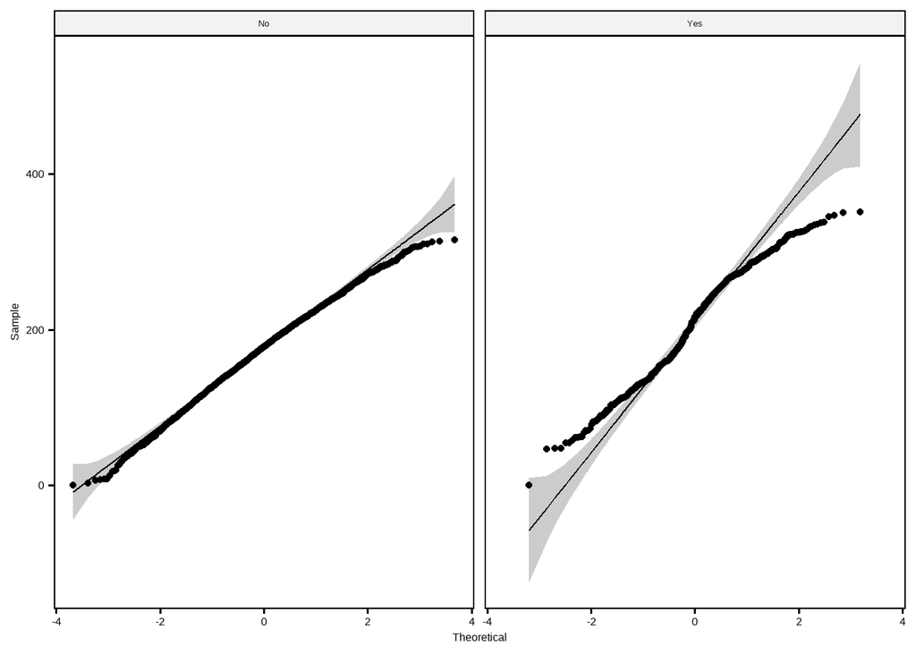

```r
ggqqplot(df, "totaldayminutes", facet.by = "churn")
```

The normality test results for the `totaldayminutes` variable across different groups indicate that the `totaldayminutes` variable does not follow a normal distribution for all groups. This result suggests that the assumption of normality has been violated.

### Variance test: `totaldayminutes` and `churn`

```r
leveneTest(totaldayminutes ~ churn, df)
```

```
## Levene's Test for Homogeneity of Variance (center = median)
##         Df F value    Pr(>F)
## group    1  240.59 < 2.2e-16 ***
##       4998
## ---
## Signif. codes:  0 '***' 0.001 '**' 0.01 '*' 0.05 '.' 0.1 ' ' 1
```

The results from Levene’s Test for Homogeneity of Variance indicates a rejection of the null hypothesis that the variances are equal across groups. Therefore, it can be concluded that there is a significant difference in the variances of the `totaldayminutes` variable across different clusters. This result suggests that the assumption of homogeneity of variances has been violated.

### Between-Subjects Comparisons: `totaldayminutes` and `churn`

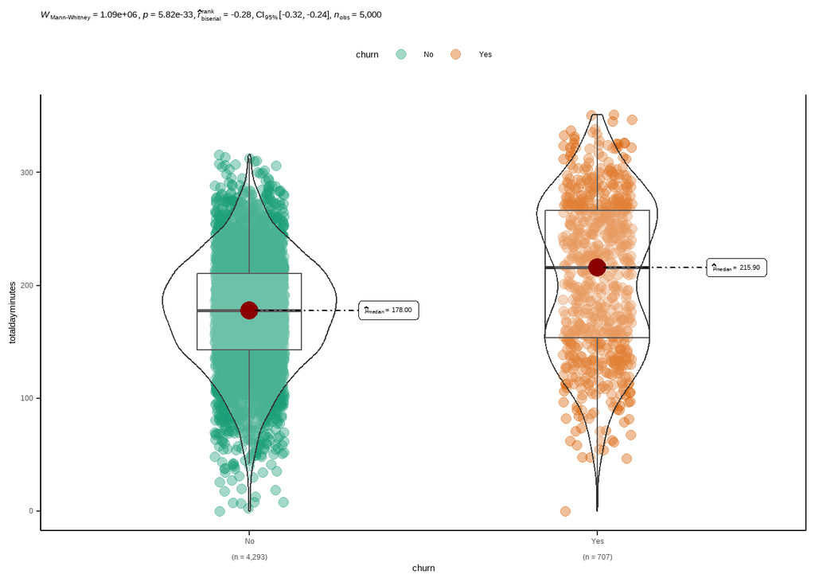

```r
ggbetweenstats(
  data = df,
  x    = churn,
  y    = totaldayminutes,
  type = "nonparametric",
  var.equal = FALSE
  ) +
  theme_classic() +
  theme(legend.position = "top")
```

Given the violation of the assumptions of normality, a non-parametric statistical test is employed with unequal variance. The Mann-Whitney U test, a non-parametric method, is utilized in this case.

The result of the test indicates a rejection of the null hypothesis, as evidenced by a p-value of 5.82e-33 and a confidence interval of [-0.32, -0.24]. This suggests that the total number of minutes the customer used during the day is significantly different between the churn group and non-churn group.

It’s crucial to note that these differences are observed in rank-sums, not medians.

### Interpretation of Effect Size: `totaldayminutes` and `churn`

```r
interpret_rank_biserial(-0.28)
```

```
## [1] "medium"
## (Rules: funder2019)
```

The rank biserial value of 0.28 is interpreted as ‘medium’ according to Funder & Ozer (2019) guidelines, indicating a medium effect size.

### Diagnosis of Outlier: `totaldayminutes` and `churn`

```r
df %>%
  group_by(churn) %>%
  diagnose_outlier(totaldayminutes) %>%
  flextable()
```

| variables | churn | data_cnt | outliers_cnt | outliers_ratio | outliers_mean | with_mean | without_mean |
| --- | --- | --- | --- | --- | --- | --- | --- |
| totaldayminutes | No | 4,293 | 26 | 0.6056371 | 47.00769 | 175.7466 | 176.5310 |
| totaldayminutes | Yes | 707 | 0 | 0.0000000 |  | 207.8706 | 207.8706 |

Outlier diagnostics indicate that there is no presence of potentially influential outliers in the dataset. As a result, the application of robust statistical testing methods is not necessary.

### Normality test: `totaldaycharge` and `churn`

```r
df %>%
  group_by(churn) %>%
  normality(totaldaycharge) %>%
  flextable()
```

| variable | churn | statistic | p_value | sample |
| --- | --- | --- | --- | --- |
| totaldaycharge | No | 0.9967332 | 0.000000046809518 | 4,293 |
| totaldaycharge | Yes | 0.9760067 | 0.000000002292273 | 707 |

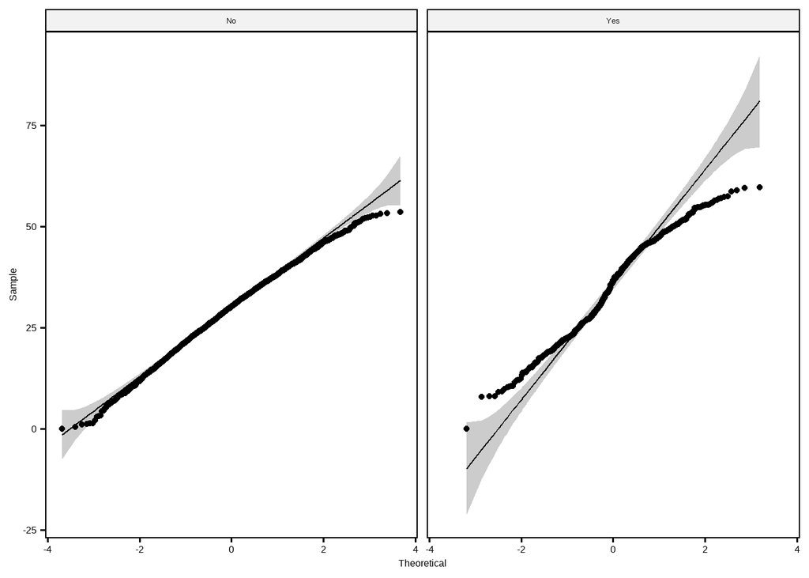

```r
ggqqplot(df, "totaldaycharge", facet.by = "churn")
```

The normality test results for the `totaldaycharge` variable across different groups indicate that the `totaldaycharge` variable does not follow a normal distribution for all groups. This result suggests that the assumption of normality has been violated.

### Variance test: `totaldaycharge` and `churn`

```r
leveneTest(totaldaycharge ~ churn, df)
```

```
## Levene's Test for Homogeneity of Variance (center = median)
##         Df F value    Pr(>F)
## group    1  240.62 < 2.2e-16 ***
##       4998
## ---
## Signif. codes:  0 '***' 0.001 '**' 0.01 '*' 0.05 '.' 0.1 ' ' 1
```

The results from Levene’s Test for Homogeneity of Variance indicates a rejection of the null hypothesis that the variances are equal across groups. Therefore, it can be concluded that there is a significant difference in the variances of the `totaldaycharge` variable across different clusters. This result suggests that the assumption of homogeneity of variances has been violated.

### Between-Subjects Comparisons: `totaldaycharge` and `churn`

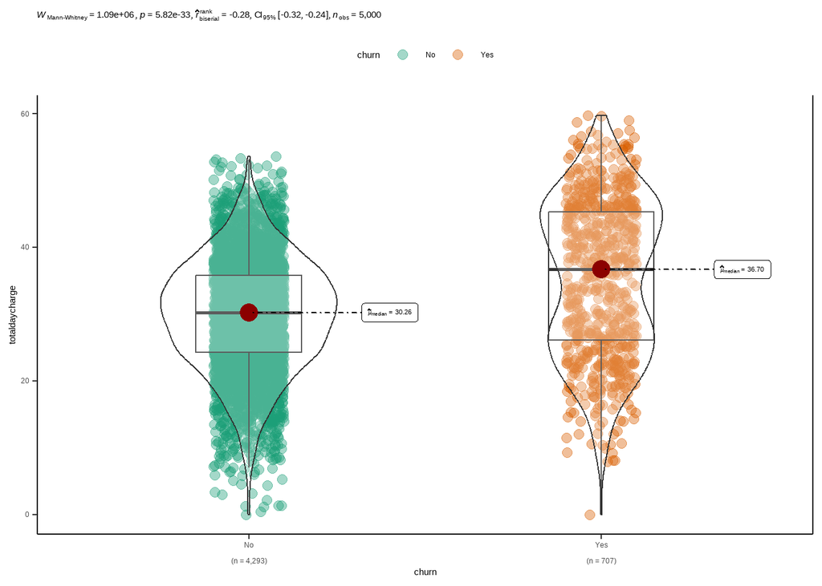

```r
ggbetweenstats(
  data = df,
  x    = churn,
  y    = totaldaycharge,
  type = "nonparametric",
  var.equal = FALSE
  ) +
  theme_classic() +
  theme(legend.position = "top")
```

Given the violation of the assumptions of normality, a non-parametric statistical test is employed with unequal variance. The Mann-Whitney U test, a non-parametric method, is utilized in this case.

The result of the test indicates a rejection of the null hypothesis, as evidenced by a p-value of 5.82e-33 and a confidence interval of [-0.32, -0.24]. This suggests that total charge for the customer’s day usage is significantly different between the churn group and non-churn group.

It’s crucial to note that these differences are observed in rank-sums, not medians.

### Interpretation of Effect Size: `totaldaycharge` and `churn`

```r
interpret_rank_biserial(-0.28)
```

```
## [1] "medium"
## (Rules: funder2019)
```

The rank biserial value of 0.28 is interpreted as ‘medium’ according to Funder & Ozer (2019) guidelines, indicating a medium effect size.

### Diagnosis of Outlier: `totaldaycharge` and `churn`

```r
df %>%
  group_by(churn) %>%
  diagnose_outlier(totaldaycharge) %>%
  flextable()
```

| variables | churn | data_cnt | outliers_cnt | outliers_ratio | outliers_mean | with_mean | without_mean |
| --- | --- | --- | --- | --- | --- | --- | --- |
| totaldaycharge | No | 4,293 | 25 | 0.5823433 | 8.0312 | 29.87749 | 30.00546 |
| totaldaycharge | Yes | 707 | 0 | 0.0000000 |  | 35.33842 | 35.33842 |

Outlier diagnostics indicate that there is no presence of potentially influential outliers in the dataset. As a result, the application of robust statistical testing methods is not necessary.

### Normality test: `totalevecalls` and `churn`

```r
df %>%
  group_by(churn) %>%
  normality(totalevecalls) %>%
  flextable()
```

| variable | churn | statistic | p_value | sample |
| --- | --- | --- | --- | --- |
| totalevecalls | No | 0.9988721 | 0.005209416 | 4,293 |
| totalevecalls | Yes | 0.9974028 | 0.331788824 | 707 |

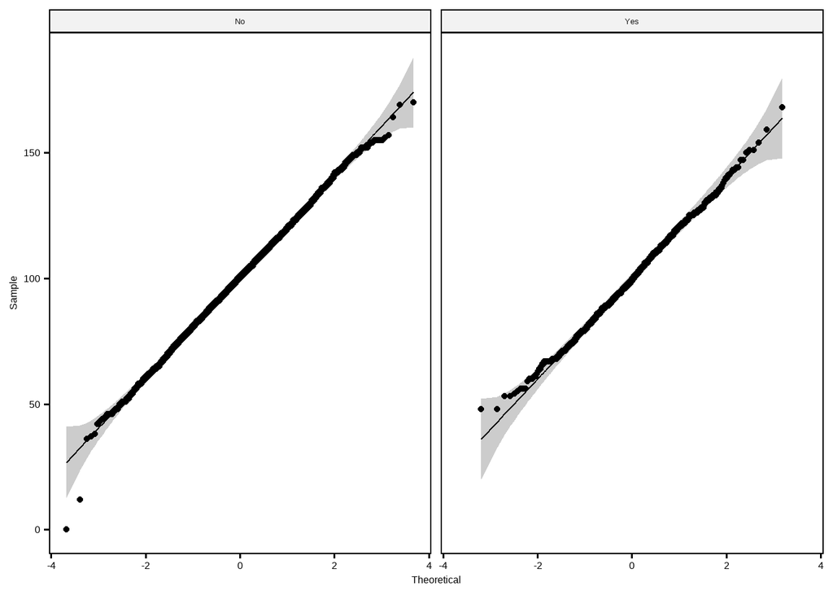

```r
ggqqplot(df, "totalevecalls", facet.by = "churn")
```

### Variance test: `totalevecalls` and `churn`

```r
leveneTest(totalevecalls ~ churn, df)
```

```
## Levene's Test for Homogeneity of Variance (center = median)
##         Df F value Pr(>F)
## group    1   0.045 0.8321
##       4998
```

The results from Levene’s Test for Homogeneity of Variance indicate that the null hypothesis, which assumes equal variances across groups, cannot be rejected. Therefore, we can conclude that there isn’t a significant difference in the variances of the `totalevecalls` variable across different clusters. This suggests that the assumption of homogeneity of variances has not been violated.

### Between-Subjects Comparisons: `totalevecalls` and `churn`

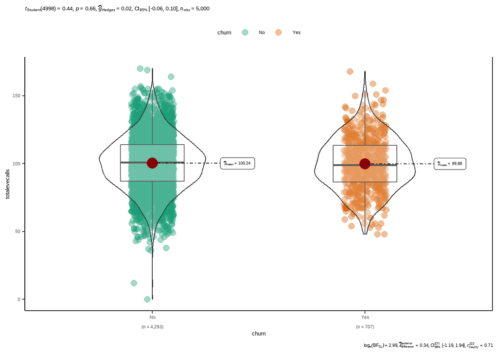

```r
ggbetweenstats(
  data = df,
  x    = churn,
  y    = totalevecalls,
  type = "parametric",
  var.equal = TRUE
) +
  theme_classic() +
  theme(legend.position = "top")
```

Test results indicate that the null hypothesis cannot be rejected. This is supported by a p-value of 0.66 and a confidence interval of [-0.06, 0.10]. This finding suggests that there is no significant difference in the total number of evening calls made by customers between the churn group and non-churn group.

### Interpretation of Effect Size: `totalevecalls` and `churn`

```r
interpret_hedges_g(0.02)
```

```
## [1] "very small"
## (Rules: cohen1988)
```

The Hedge’s g value of 0.02 is interpreted as ‘very small’ according to Cohen (1988) guidelines, indicating a very small effect size.

### Interpretation of Bayes Factor: `totalevecalls` and `churn`

```r
interpret_bf(2.99,log = T)
```

```
## [1] "strong evidence in favour of"
## (Rules: jeffreys1961)
```

The Bayes Factor value of 2.99 is interpreted as ‘strong evidence in favour of’ according to Jeffreys (1961) guidelines, indicating strong evidence to support the null hypothesis.

### Diagnosis of Outlier: `totalevecalls` and `churn`

```r
df %>%
  group_by(churn) %>%
  diagnose_outlier(totalevecalls) %>%
  flextable()
```

| variables | churn | data_cnt | outliers_cnt | outliers_ratio | outliers_mean | with_mean | without_mean |
| --- | --- | --- | --- | --- | --- | --- | --- |
| totalevecalls | No | 4,293 | 25 | 0.5823433 | 86.48 | 100.24156 | 100.32216 |
| totalevecalls | Yes | 707 | 2 | 0.2828854 | 163.50 | 99.88402 | 99.70355 |

Outlier diagnostics indicate that there is no presence of potentially influential outliers in the dataset. As a result, the application of robust statistical testing methods is not necessary.

### Normality test: `totalnightcalls` and `churn`

```r
df %>%
  group_by(churn) %>%
  normality(totalnightcalls) %>%
  flextable()
```

| variable | churn | statistic | p_value | sample |
| --- | --- | --- | --- | --- |
| totalnightcalls | No | 0.9988801 | 0.005493788 | 4,293 |
| totalnightcalls | Yes | 0.9977484 | 0.465537890 | 707 |

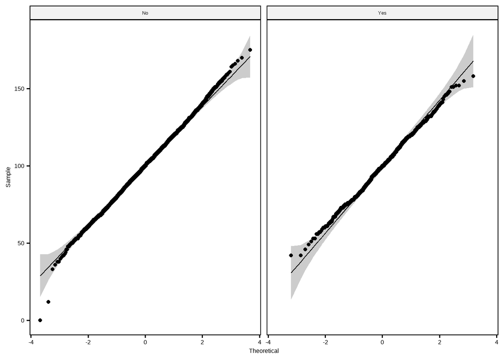

```r
ggqqplot(df, "totalnightcalls", facet.by = "churn")
```

### Variance test: `totalnightcalls` and `churn`

```r
leveneTest(totalnightcalls ~ churn, df)
```

```
## Levene's Test for Homogeneity of Variance (center = median)
##         Df F value Pr(>F)
## group    1   0.158  0.691
##       4998
```

The results from Levene’s Test for Homogeneity of Variance indicate that the null hypothesis, which assumes equal variances across groups, cannot be rejected. Therefore, we can conclude that there isn’t a significant difference in the variances of the `totalnightcalls` variable across different clusters. This suggests that the assumption of homogeneity of variances has not been violated.

### Between-Subjects Comparisons: `totalnightcalls` and `churn`

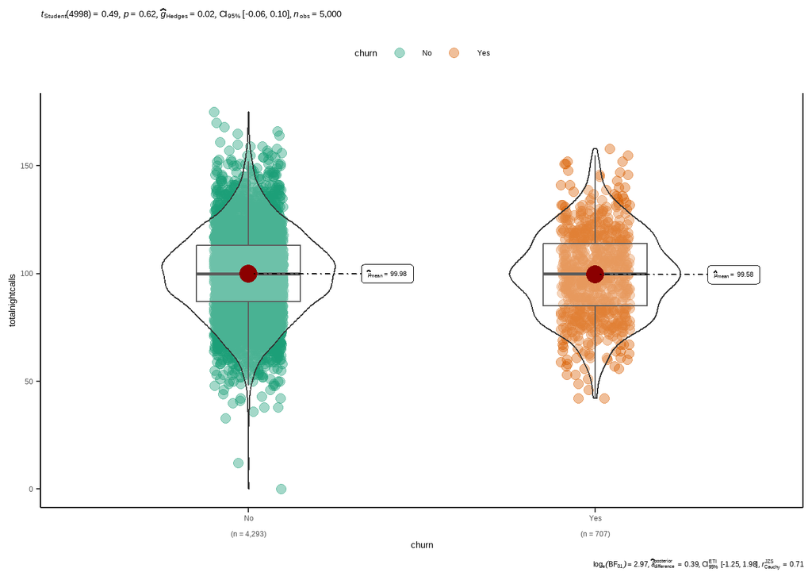

```r
ggbetweenstats(
  data = df,
  x    = churn,
  y    = totalnightcalls,
  type = "parametric",
  var.equal = TRUE
  ) +
  theme_classic() +
  theme(legend.position = "top")
```

Test results indicate that the null hypothesis cannot be rejected. This is supported by a p-value of 0.62 and a confidence interval of [-0.06, 0.10]. This finding suggests that there is no significant difference in the total number of calls the customer made during the night between the churn group and non-churn group.

### Interpretation of Effect Size: `totalnightcalls` and `churn`

```r
interpret_hedges_g(0.02)
```

```
## [1] "very small"
## (Rules: cohen1988)
```

The Hedge’s g value of 0.02 is interpreted as ‘very small’ according to Cohen (1988) guidelines, indicating a very small effect size.

### Interpretation of Bayes Factor: `totalnightcalls` and `churn`

```r
interpret_bf(2.97,log = T)
```

```
## [1] "strong evidence in favour of"
## (Rules: jeffreys1961)
```

The Bayes Factor value of 2.97 is interpreted as ‘strong evidence in favour of’ according to Jeffreys (1961) guidelines, indicating strong evidence to support the null hypothesis.

### Diagnosis of Outlier: `totalnightcalls` and `churn`

```r
df %>%
  group_by(churn) %>%
  diagnose_outlier(totalnightcalls) %>%
  flextable()
```

| variables | churn | data_cnt | outliers_cnt | outliers_ratio | outliers_mean | with_mean | without_mean |
| --- | --- | --- | --- | --- | --- | --- | --- |
| totalnightcalls | No | 4,293 | 38 | 0.8851619 | 113.6316 | 99.97577 | 99.85382 |
| totalnightcalls | Yes | 707 | 1 | 0.1414427 | 158.0000 | 99.57567 | 99.49292 |

Outlier diagnostics indicate that there is no presence of potentially influential outliers in the dataset. As a result, the application of robust statistical testing methods is not necessary.

### Normality test: `totaleveminutes` and `churn`

```r
df %>%
  group_by(churn) %>%
  normality(totaleveminutes) %>%
  flextable()
```

| variable | churn | statistic | p_value | sample |
| --- | --- | --- | --- | --- |
| totaleveminutes | No | 0.9995459 | 0.4261375 | 4,293 |
| totaleveminutes | Yes | 0.9977360 | 0.4602152 | 707 |

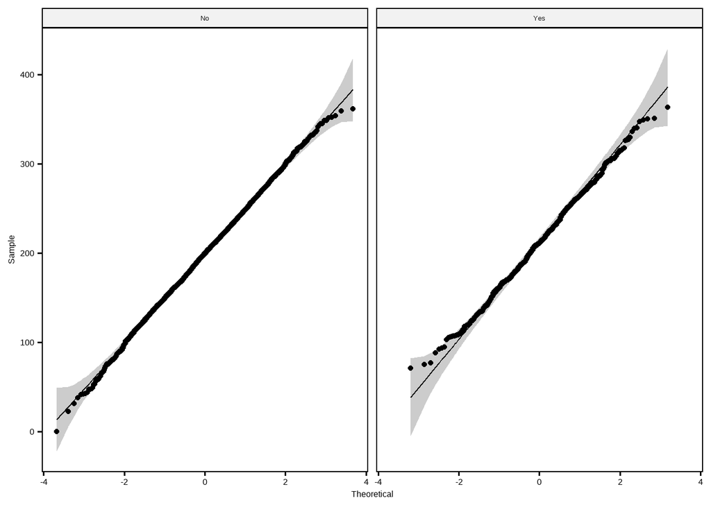

```r
ggqqplot(df, "totaleveminutes", facet.by = "churn")
```

The normality test results for the `totaleveminutes` variable across different groups indicate that the `totaleveminutes` variable follow a normal distribution for all groups. This result suggests that the assumption of normality has not been violated.

### Variance test: `totaleveminutes` and `churn`

```r
leveneTest(totaleveminutes ~ churn, df)
```

```
## Levene's Test for Homogeneity of Variance (center = median)
##         Df F value Pr(>F)
## group    1   1.408 0.2355
##       4998
```

The results from Levene’s Test for Homogeneity of Variance indicate that the null hypothesis, which assumes equal variances across groups, cannot be rejected. Therefore, we can conclude that there isn’t a significant difference in the variances of the `totaleveminutes` variable across different clusters. This suggests that the assumption of homogeneity of variances has not been violated.

### Between-Subjects Comparisons: `totaleveminutes` and `churn`

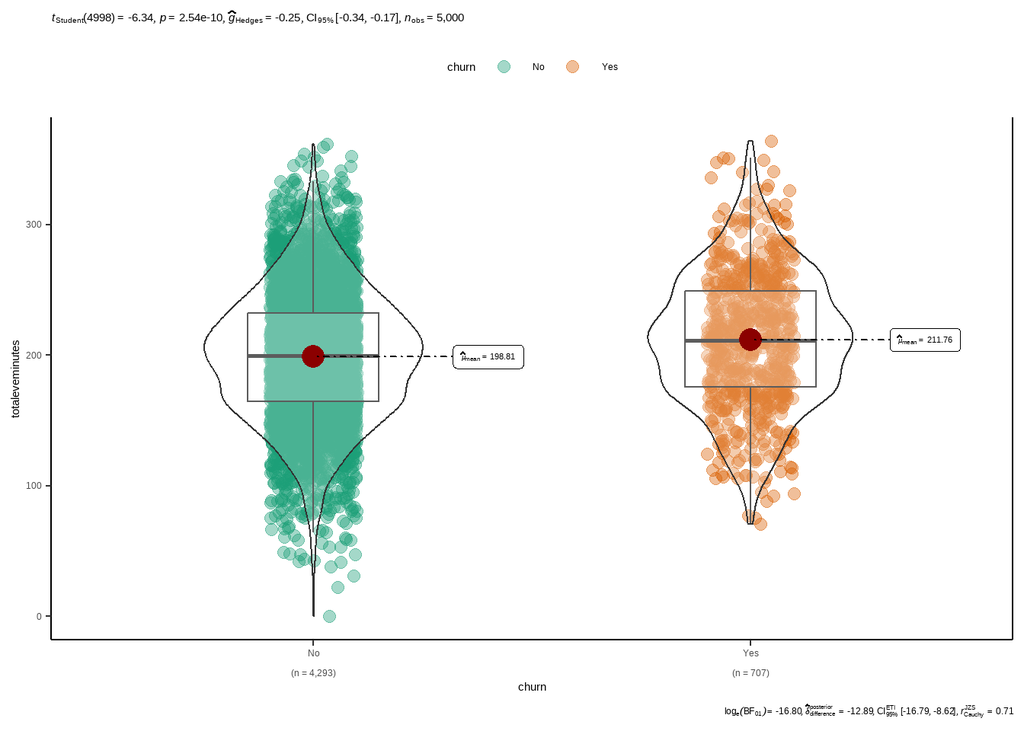

```r
ggbetweenstats(
  data = df,
  x    = churn,
  y    = totaleveminutes,
  type = "parametric",
  var.equal = TRUE
  ) +
  theme_classic() +
  theme(legend.position = "top")
```

Given that assumptions of normality and homogeneity of variance are not violated, a parametric statistical test with equal variance is employed. In this case, the Student’s t-test, a parametric method, is utilized.

Test results indicate that the null hypothesis can be rejected. This is supported by a p-value of 2.54e-10 and a confidence interval of [-0.34, -0.17]. This finding suggests that there is significant difference in the total number of minutes the customer used during the evening between the churn group and non-churn group. The mean total evening minutes for the churn group is 211.76, while for the non-churn group it is 198.81. This suggests that, on average, customers in the churn group have higher total evening minutes than those in the non-churn group.

### Interpretation of Effect Size: `totaleveminutes` and `churn`

```r
interpret_hedges_g(-0.25)
```

```
## [1] "small"
## (Rules: cohen1988)
```

The Hedge’s g value of -0.25 is interpreted as ‘small’ according to Cohen (1988) guidelines, indicating a small effect size.

### Interpretation of Bayes Factor: `totaleveminutes` and `churn`

```r
interpret_bf(-16.80,log = T)
```

```
## [1] "extreme evidence against"
## (Rules: jeffreys1961)
```

The Bayes Factor value of -16.80 is interpreted as ‘extreme evidence against’ according to Jeffreys (1961) guidelines, indicating extreme evidence against the null hypothesis.

### Diagnosis of Outlier: `totaleveminutes` and `churn`

```r
df %>%
  group_by(churn) %>%
  diagnose_outlier(totaleveminutes) %>%
  flextable()
```

| variables | churn | data_cnt | outliers_cnt | outliers_ratio | outliers_mean | with_mean | without_mean |
| --- | --- | --- | --- | --- | --- | --- | --- |
| totaleveminutes | No | 4,293 | 36 | 0.8385744 | 171.325 | 198.8050 | 199.0374 |
| totaleveminutes | Yes | 707 | 1 | 0.1414427 | 363.700 | 211.7579 | 211.5426 |

Outlier diagnostics indicate that there is no presence of potentially influential outliers in the dataset. As a result, the application of robust statistical testing methods is not necessary.

### Normality test: `totalevecharge` and `churn`

```r
df %>%
  group_by(churn) %>%
  normality(totalevecharge) %>%
  flextable()
```

| variable | churn | statistic | p_value | sample |
| --- | --- | --- | --- | --- |
| totalevecharge | No | 0.9995453 | 0.4249319 | 4,293 |
| totalevecharge | Yes | 0.9977327 | 0.4587858 | 707 |

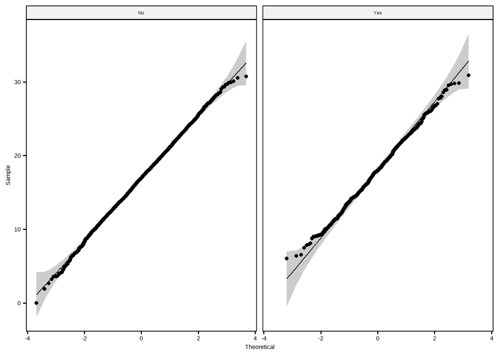

```r
ggqqplot(df, "totalevecharge", facet.by = "churn")
```

The normality test results for the `totalevecharge` variable across different groups indicate that the `totalevecharge` variable follow a normal distribution for all groups. This result suggests that the assumption of normality has not been violated.

### Variance test: `totalevecharge` and `churn`

```r
leveneTest(totalevecharge ~ churn, df)
```

```
## Levene's Test for Homogeneity of Variance (center = median)
##         Df F value Pr(>F)
## group    1  1.4042 0.2361
##       4998
```

The results from Levene’s Test for Homogeneity of Variance indicate that the null hypothesis, which assumes equal variances across groups, cannot be rejected. Therefore, we can conclude that there isn’t a significant difference in the variances of the `totalevecharge` variable across different clusters. This suggests that the assumption of homogeneity of variances has not been violated.

### Between-Subjects Comparisons: `totalevecharge` and `churn`

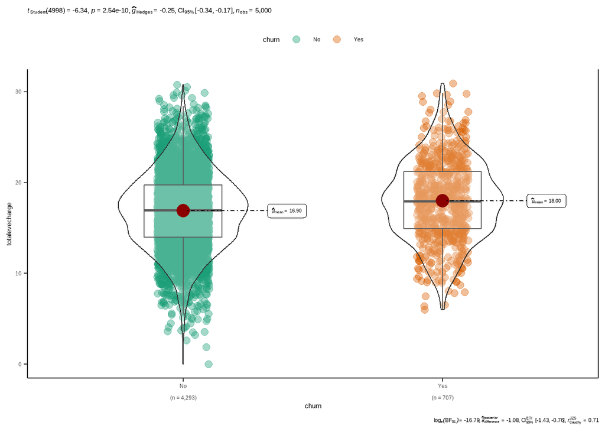

```r
ggbetweenstats(
  data = df,
  x    = churn,
  y    = totalevecharge,
  type = "parametric",
  var.equal = TRUE
  ) +
  theme_classic() +
  theme(legend.position = "top")
```

Given that assumptions of normality and homogeneity of variance are not violated, a parametric statistical test with equal variance is employed. In this case, the Student’s t-test, a parametric method, is utilized.

Test results indicate that the null hypothesis can be rejected. This is supported by a p-value of 2.54e-10 and a confidence interval of [-0.34, -0.17]. This finding suggests that there is significant difference in the total charge for the customer’s evening usage between the churn group and non-churn group. The mean total evening charge for the churn group is 18, while for the non-churn group it is 16.90. This suggests that, on average, customers in the churn group have a higher total evening charge than those in the non-churn group.

### Interpretation of Effect Size: `totalevecharge` and `churn`

```r
interpret_hedges_g(-0.25)
```

```
## [1] "small"
## (Rules: cohen1988)
```

The Hedge’s g value of -0.25 is interpreted as ‘small’ according to Cohen (1988) guidelines, indicating a small effect size.

### Interpretation of Bayes Factor: `totalevecharge` and `churn`

```r
interpret_bf(-16.79,log = T)
```

```
## [1] "extreme evidence against"
## (Rules: jeffreys1961)
```

The Bayes Factor value of -16.79 is interpreted as ‘extreme evidence against’ according to Jeffreys (1961) guidelines, indicating extreme evidence against the null hypothesis.

### Diagnosis of Outlier: `totalevecharge` and `churn`

```r
df %>%
  group_by(churn) %>%
  diagnose_outlier(totalevecharge) %>%
  flextable()
```

| variables | churn | data_cnt | outliers_cnt | outliers_ratio | outliers_mean | with_mean | without_mean |
| --- | --- | --- | --- | --- | --- | --- | --- |
| totalevecharge | No | 4,293 | 35 | 0.8152807 | 14.16743 | 16.89865 | 16.92110 |
| totalevecharge | Yes | 707 | 1 | 0.1414427 | 30.91000 | 17.99956 | 17.98127 |

Outlier diagnostics indicate that there is no presence of potentially influential outliers in the dataset. As a result, the application of robust statistical testing methods is not necessary.

### Normality test: `totalintlcharge` and `churn`

```r
df %>%
  group_by(churn) %>%
  normality(totalintlcharge) %>%
  flextable()
```

| variable | churn | statistic | p_value | sample |
| --- | --- | --- | --- | --- |
| totalintlcharge | No | 0.9926432 | 0.00000000000004373336 | 4,293 |
| totalintlcharge | Yes | 0.9970491 | 0.22763698498659173941 | 707 |

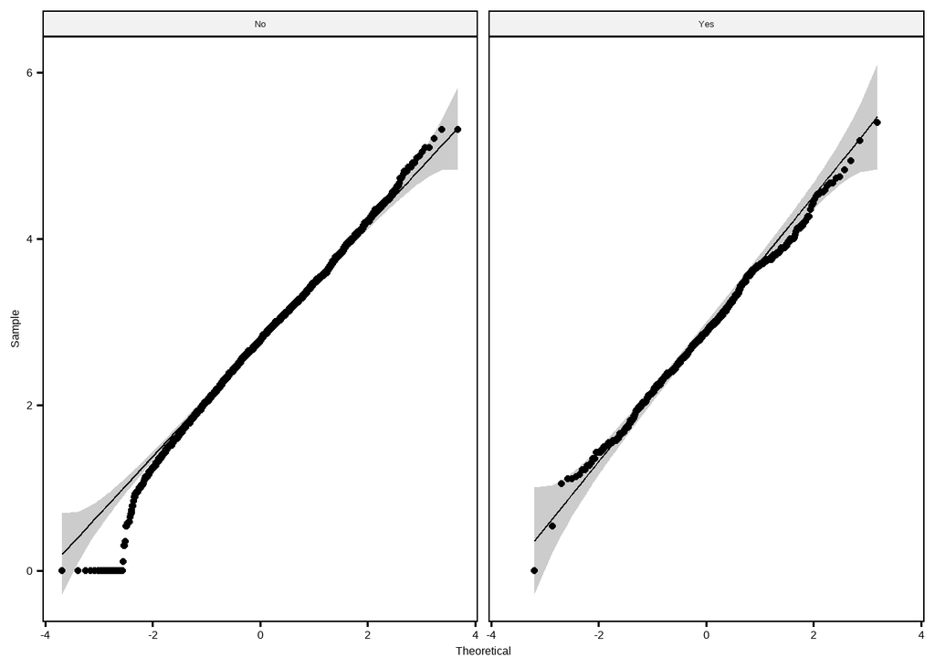

```r
ggqqplot(df, "totalintlcharge", facet.by = "churn")
```

### Variance test: `totalintlcharge` and `churn`

```r
leveneTest(totalintlcharge ~ churn, df)
```

```
## Levene's Test for Homogeneity of Variance (center = median)
##         Df F value Pr(>F)
## group    1  1.3047 0.2534
##       4998
```

The results from Levene’s Test for Homogeneity of Variance indicate that the null hypothesis, which assumes equal variances across groups, cannot be rejected. Therefore, we can conclude that there isn’t a significant difference in the variances of the `totalintlcharge` variable across different clusters. This suggests that the assumption of homogeneity of variances has not been violated.

### Between-Subjects Comparisons: `totalintlcharge` and `churn`

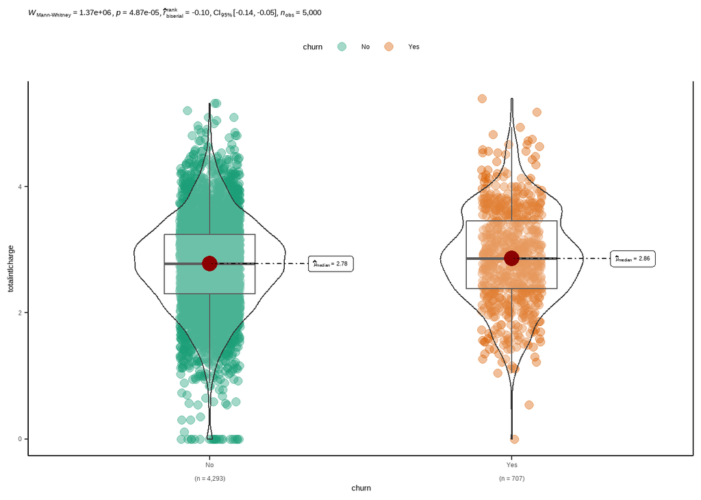

```r
ggbetweenstats(
  data = df,
  x    = churn,
  y    = totalintlcharge,
  type = "nonparametric",
  var.equal = TRUE
  ) +
  theme_classic() +
  theme(legend.position = "top")
```

### Interpretation of Effect Size: `totalintlcharge` and `churn`

```r
interpret_rank_biserial(-0.10)
```

```
## [1] "small"
## (Rules: funder2019)
```

The rank biserial value of 0.10 is interpreted as ‘small’ according to Funder & Ozer (2019) guidelines, indicating a small effect size.

### Diagnosis of Outlier: `totalintlcharge` and `churn`

```r
df %>%
  group_by(churn) %>%
  diagnose_outlier(totalintlcharge) %>%
  flextable()
```

| variables | churn | data_cnt | outliers_cnt | outliers_ratio | outliers_mean | with_mean | without_mean |
| --- | --- | --- | --- | --- | --- | --- | --- |
| totalintlcharge | No | 4,293 | 62 | 1.4442115 | 1.839032 | 2.752055 | 2.765434 |
| totalintlcharge | Yes | 707 | 4 | 0.5657709 | 2.780000 | 2.887426 | 2.888037 |

Outlier diagnostics indicate that there is no presence of potentially influential outliers in the dataset. As a result, the application of robust statistical testing methods is not necessary.

### Normality test: `totalnightcharge` and `churn`

```r
df %>%
  group_by(churn) %>%
  normality(totalnightcharge) %>%
  flextable()
```

| variable | churn | statistic | p_value | sample |
| --- | --- | --- | --- | --- |
| totalnightcharge | No | 0.9997148 | 0.8481255 | 4,293 |
| totalnightcharge | Yes | 0.9987082 | 0.8978807 | 707 |

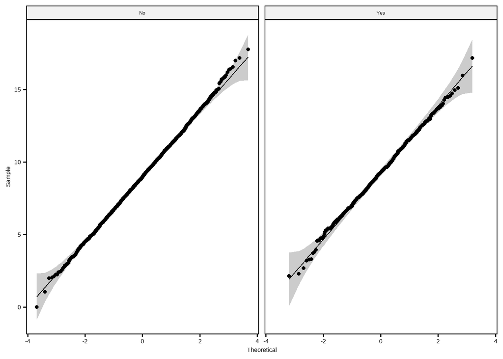

```r
ggqqplot(df, "totalnightcharge", facet.by = "churn")
```

The normality test results for the `totalnightcharge` variable across different groups indicate that the `totalnightcharge` variable follow a normal distribution for all groups. This result suggests that the assumption of normality has not been violated.

### Variance test: `totalnightcharge` and `churn`

```r
leveneTest(totalnightcharge ~ churn, df)
```

```
## Levene's Test for Homogeneity of Variance (center = median)
##         Df F value Pr(>F)
## group    1  0.4634 0.4961
##       4998
```

The results from Levene’s Test for Homogeneity of Variance indicate that the null hypothesis, which assumes equal variances across groups, cannot be rejected. Therefore, we can conclude that there isn’t a significant difference in the variances of the `totalnightcharge` variable across different clusters. This suggests that the assumption of homogeneity of variances has not been violated.

### Between-Subjects Comparisons: `totalnightcharge` and `churn`

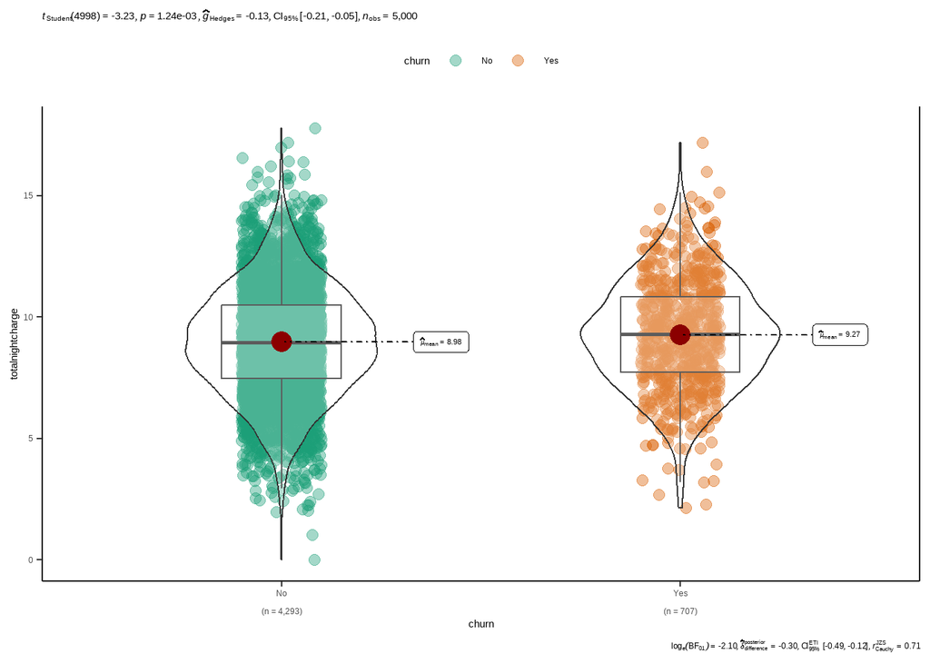

```r
ggbetweenstats(
  data = df,
  x    = churn,
  y    = totalnightcharge,
  type = "parametric",
  var.equal = TRUE
  ) +
  theme_classic() +
  theme(legend.position = "top")
```

Given that assumptions of normality and homogeneity of variance are not violated, a parametric statistical test with equal variance is employed. In this case, the Student’s t-test, a parametric method, is utilized.

Test results indicate that the null hypothesis can be rejected. This is supported by a p-value of 1.24e-03 and a confidence interval of [-0.21, -0.05]. This finding suggests that there is significant difference in the total charge for the customer’s night usage between the churn group and non-churn group. The mean total night charge for the churn group is 9.27, while for the non-churn group it is 8.98. This suggests that, on average, customers in the churn group have a higher total night charge than those in the non-churn group.

### Interpretation of Effect Size: `totalnightcharge` and `churn`

```r
interpret_hedges_g(-0.13)
```

```
## [1] "very small"
## (Rules: cohen1988)
```

The Hedge’s g value of -0.13 is interpreted as ‘very small’ according to Cohen (1988) guidelines, indicating a very small effect size.

### Interpretation of Bayes Factor: `totalnightcharge` and `churn`

```r
interpret_bf(-2.10,log = T)
```

```
## [1] "moderate evidence against"
## (Rules: jeffreys1961)
```

The Bayes Factor value of -2.10 is interpreted as ‘moderate evidence against’ according to Jeffreys (1961) guidelines, indicating moderate evidence against the null hypothesis.

### Diagnosis of Outlier: `totalnightcharge` and `churn`

```r
df %>%
  group_by(churn) %>%
  diagnose_outlier(totalnightcharge) %>%
  flextable()
```

| variables | churn | data_cnt | outliers_cnt | outliers_ratio | outliers_mean | with_mean | without_mean |
| --- | --- | --- | --- | --- | --- | --- | --- |
| totalnightcharge | No | 4,293 | 34 | 0.7919870 | 9.178824 | 8.975593 | 8.973970 |
| totalnightcharge | Yes | 707 | 5 | 0.7072136 | 8.048000 | 9.273607 | 9.282336 |

Outlier diagnostics indicate that there is no presence of potentially influential outliers in the dataset. As a result, the application of robust statistical testing methods is not necessary.

### Normality test: `totalintlminutes` and `churn`

```r
df %>%
  group_by(churn) %>%
  normality(totalintlminutes) %>%
  flextable()
```

| variable | churn | statistic | p_value | sample |
| --- | --- | --- | --- | --- |
| totalintlminutes | No | 0.9926745 | 0.00000000000004758785 | 4,293 |
| totalintlminutes | Yes | 0.9970329 | 0.22363145460100486428 | 707 |

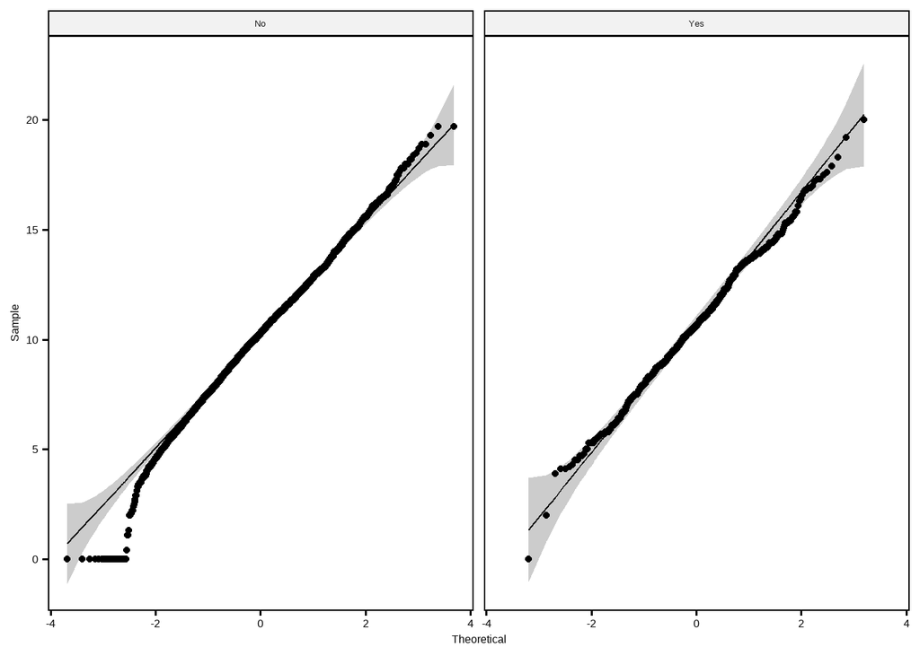

```r
ggqqplot(df, "totalintlminutes", facet.by = "churn")
```

The normality test results for the `totalintlminutes` variable across different groups indicate that the `totalintlminutes` variable does not follow a normal distribution for all groups. This result suggests that the assumption of normality has been violated.

### Variance test: `totalintlminutes` and `churn`

```r
leveneTest(totalintlminutes ~ churn, df)
```

```
## Levene's Test for Homogeneity of Variance (center = median)
##         Df F value Pr(>F)
## group    1   1.318  0.251
##       4998
```

The results from Levene’s Test for Homogeneity of Variance indicate that the null hypothesis, which assumes equal variances across groups, cannot be rejected. Therefore, we can conclude that there isn’t a significant difference in the variances of the `totalintlminutes` variable across different clusters. This suggests that the assumption of homogeneity of variances has not been violated.

### Between-Subjects Comparisons: `totalintlminutes` and `churn`

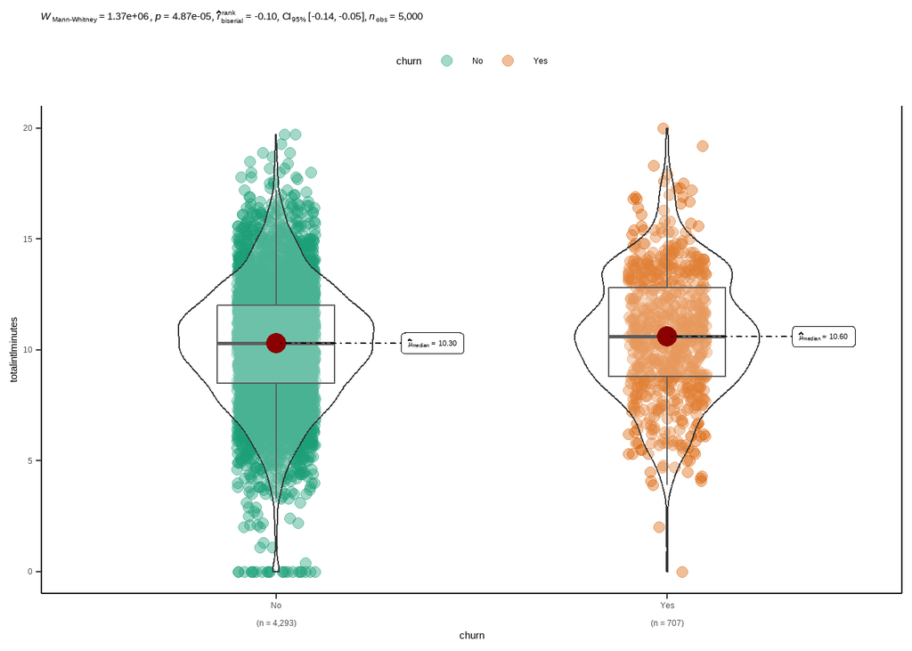

```r
ggbetweenstats(
  data = df,
  x    = churn,
  y    = totalintlminutes,
  type = "nonparametric",
  var.equal = TRUE
  ) +
  theme_classic() +
  theme(legend.position = "top")
```

The result of the test indicates a rejection of the null hypothesis, as evidenced by a p-value of 4.87e-05 and a confidence interval of [-0.14, -0.05]. This suggests that the total number of international minutes the customer used is significantly different between the churn group and non-churn group.

It’s crucial to note that these differences are observed in rank-sums, not medians.

### Interpretation of Effect Size: `totalintlminutes` and `churn`

```r
interpret_rank_biserial(-0.10)
```

```
## [1] "small"
## (Rules: funder2019)
```

The rank biserial value of 0.10 is interpreted as ‘small’ according to Funder & Ozer (2019) guidelines, indicating a small effect size.

### Diagnosis of Outlier: `totalintlminutes` and `churn`

```r
df %>%
  group_by(churn) %>%
  diagnose_outlier(totalintlminutes) %>%
  flextable()
```

| variables | churn | data_cnt | outliers_cnt | outliers_ratio | outliers_mean | with_mean | without_mean |
| --- | --- | --- | --- | --- | --- | --- | --- |
| totalintlminutes | No | 4,293 | 62 | 1.4442115 | 6.809677 | 10.19087 | 10.24042 |
| totalintlminutes | Yes | 707 | 4 | 0.5657709 | 10.300000 | 10.69236 | 10.69459 |

Outlier diagnostics indicate that there is no presence of potentially influential outliers in the dataset. As a result, the application of robust statistical testing methods is not necessary.

### Normality test: `totalnightminutes` and `churn`

```r
df %>%
  group_by(churn) %>%
  normality(totalnightminutes) %>%
  flextable()
```

| variable | churn | statistic | p_value | sample |
| --- | --- | --- | --- | --- |
| totalnightminutes | No | 0.9997171 | 0.8530730 | 4,293 |
| totalnightminutes | Yes | 0.9987132 | 0.8995724 | 707 |

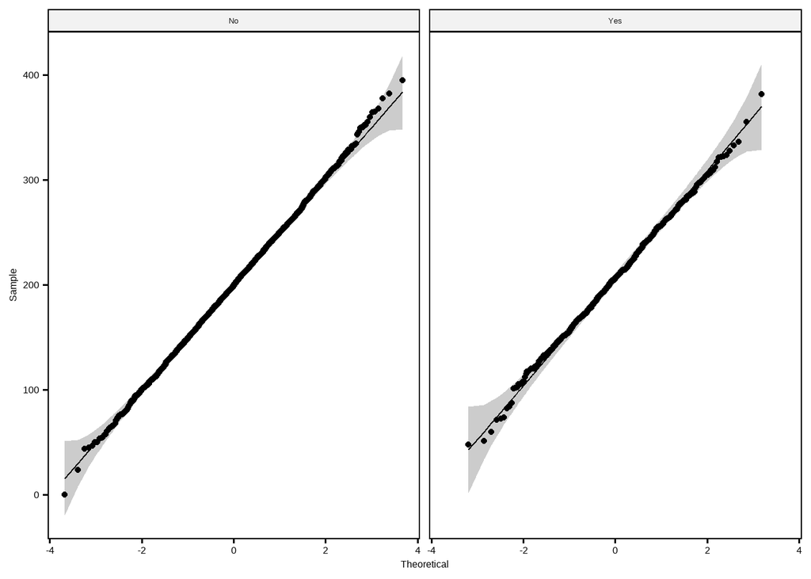

```r
ggqqplot(df, "totalnightminutes", facet.by = "churn")
```

The normality test results for the `totalnightminutes` variable across different groups indicate that the `totalnightminutes` variable follow a normal distribution for all groups. This result suggests that the assumption of normality has not been violated.

### Variance test: `totalnightminutes` and `churn`

```r
leveneTest(totalnightminutes ~ churn, df)
```

```
## Levene's Test for Homogeneity of Variance (center = median)
##         Df F value Pr(>F)
## group    1  0.4602 0.4975
##       4998
```

The results from Levene’s Test for Homogeneity of Variance indicate that the null hypothesis, which assumes equal variances across groups, cannot be rejected. Therefore, we can conclude that there isn’t a significant difference in the variances of the `totalnightminutes` variable across different clusters. This suggests that the assumption of homogeneity of variances has not been violated.

### Between-Subjects Comparisons: `totalnightminutes` and `churn`

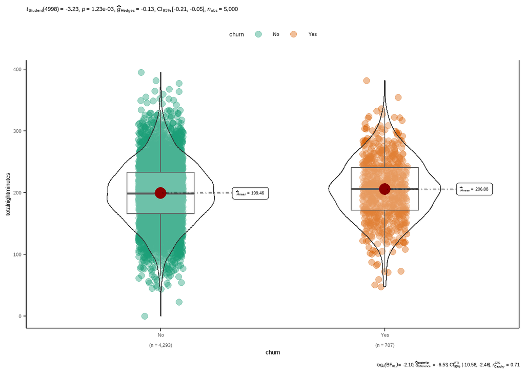

```r
ggbetweenstats(
  data = df,
  x    = churn,
  y    = totalnightminutes,
  type = "parametric",
  var.equal = TRUE
  ) +
  theme_classic() +
  theme(legend.position = "top")
```

Given that assumptions of normality and homogeneity of variance are not violated, a parametric statistical test with equal variance is employed. In this case, the Student’s t-test, a parametric method, is utilized.

Test results indicate that the null hypothesis can be rejected. This is supported by a p-value of 1.23e-03 and a confidence interval of [-0.21, -0.05]. This finding suggests that there is significant difference in the total number of minutes the customer used during the night between the churn group and non-churn group. The mean total night minutes for the churn group is 206.08, while for the non-churn group it is 199.46. This suggests that, on average, customers in the churn group have a higher number of total night minutes than those in the non-churn group.

### Interpretation of Effect Size: `totalnightminutes` and `churn`

```r
interpret_hedges_g(-0.13)
```

```
## [1] "very small"
## (Rules: cohen1988)
```

The Hedge’s g value of -0.13 is interpreted as ‘very small’ according to Cohen (1988) guidelines, indicating a very small effect size.

### Interpretation of Bayes Factor: `totalnightminutes` and `churn`

```r
interpret_bf(-2.10,log = T)
```

```
## [1] "moderate evidence against"
## (Rules: jeffreys1961)
```

The Bayes Factor value of -2.10 is interpreted as ‘moderate evidence against’ according to Jeffreys (1961) guidelines, indicating moderate evidence against the null hypothesis.

### Diagnosis of Outlier: `totalnightminutes` and `churn`

```r
df %>%
  group_by(churn) %>%
  diagnose_outlier(totalnightminutes) %>%
  flextable()
```

| variables | churn | data_cnt | outliers_cnt | outliers_ratio | outliers_mean | with_mean | without_mean |
| --- | --- | --- | --- | --- | --- | --- | --- |
| totalnightminutes | No | 4,293 | 34 | 0.7919870 | 203.9765 | 199.4551 | 199.4190 |
| totalnightminutes | Yes | 707 | 5 | 0.7072136 | 178.8600 | 206.0782 | 206.2721 |

Outlier diagnostics indicate that there is no presence of potentially influential outliers in the dataset. As a result, the application of robust statistical testing methods is not necessary.

### Normality test: `accountlength` and `churn`

```r
df %>%
  group_by(churn) %>%
  normality(accountlength) %>%
  flextable()
```

| variable | churn | statistic | p_value | sample |
| --- | --- | --- | --- | --- |
| accountlength | No | 0.9981460 | 0.00005682422 | 4,293 |
| accountlength | Yes | 0.9969988 | 0.21537679654 | 707 |

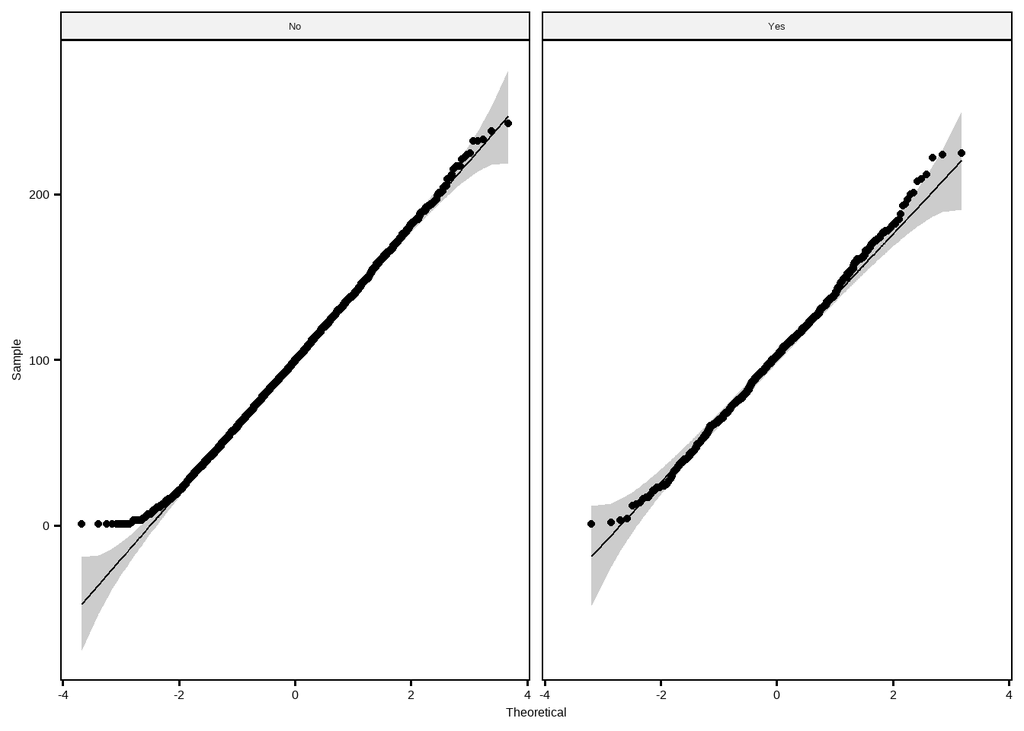

```r
ggqqplot(df, "accountlength", facet.by = "churn")
```

### Variance test: `accountlength` and `churn`

```r
leveneTest(accountlength ~ churn, df)
```

```
## Levene's Test for Homogeneity of Variance (center = median)
##         Df F value Pr(>F)
## group    1   0.471 0.4926
##       4998
```

The results from Levene’s Test for Homogeneity of Variance indicate that the null hypothesis, which assumes equal variances across groups, cannot be rejected. Therefore, we can conclude that there isn’t a significant difference in the variances of the `accountlength` variable across different clusters. This suggests that the assumption of homogeneity of variances has not been violated.

### Between-Subjects Comparisons: `accountlength` and `churn`

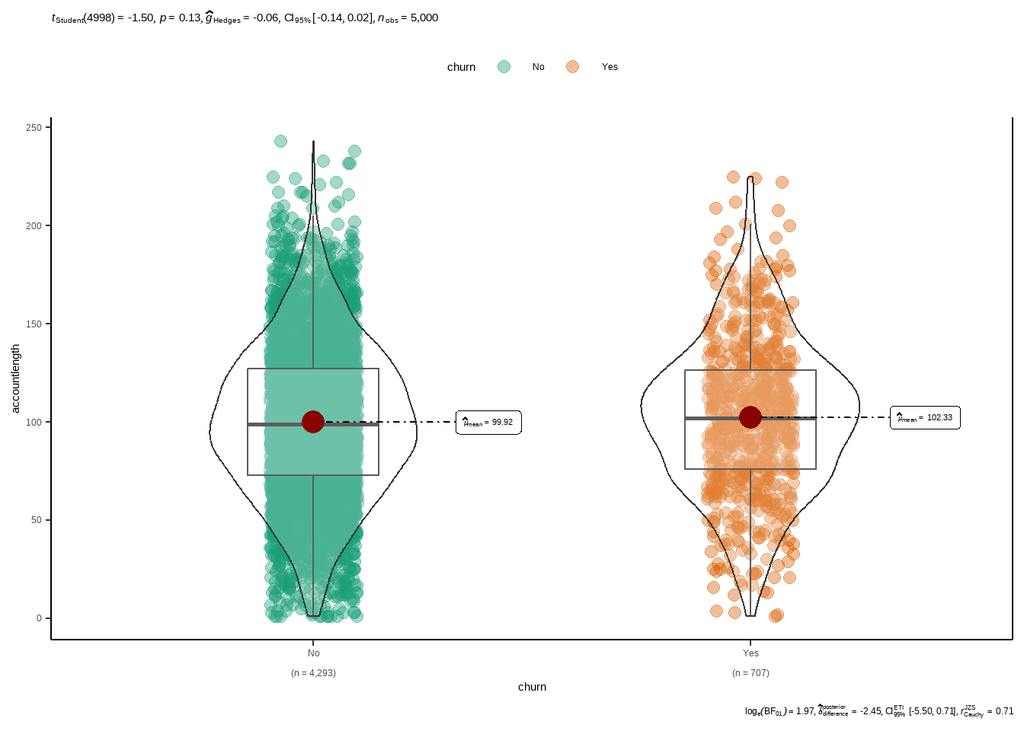

```r
ggbetweenstats(
  data = df,
  x    = churn,
  y    = accountlength,
  type = "parametric",
  var.equal = TRUE
  ) +
  theme_classic() +
  theme(legend.position = "top")
```

Given that assumptions of normality and homogeneity of variance are not violated, a parametric statistical test with equal variance is employed. In this case, the Student’s t-test, a parametric method, is utilized.

Test results indicate that the null hypothesis cannot be rejected. This is supported by a p-value of 0.13 and a confidence interval of [-0.14, 0.02]. This finding suggests that there is no significant difference in the length of the customer’s account in days between the churn group and non-churn group.

### Interpretation of Effect Size: `accountlength` and `churn`

```r
interpret_hedges_g(-0.06)
```

```
## [1] "very small"
## (Rules: cohen1988)
```

The Hedge’s g value of -0.06 is interpreted as ‘very small’ according to Cohen (1988) guidelines, indicating a very small effect size.

### Interpretation of Bayes Factor: `accountlength` and `churn`

```r
interpret_bf(1.97,log = T)
```

```
## [1] "moderate evidence in favour of"
## (Rules: jeffreys1961)
```

The Bayes Factor value of 1.97 is interpreted as ‘moderate evidence in favour of’ according to Jeffreys (1961) guidelines, indicating moderate evidence to support the null hypothesis.

### Diagnosis of Outlier: `accountlength` and `churn`

```r
df %>%
  group_by(churn) %>%
  diagnose_outlier(accountlength) %>%
  flextable()
```

| variables | churn | data_cnt | outliers_cnt | outliers_ratio | outliers_mean | with_mean | without_mean |
| --- | --- | --- | --- | --- | --- | --- | --- |
| accountlength | No | 4,293 | 19 | 0.4425809 | 221.1579 | 99.91707 | 99.3781 |
| accountlength | Yes | 707 | 6 | 0.8486563 | 216.6667 | 102.33239 | 101.3538 |

Outlier diagnostics indicate that there is no presence of potentially influential outliers in the dataset. As a result, the application of robust statistical testing methods is not necessary.

### Normality test: `totaldaycalls` and `churn`

```r
df %>%
  group_by(churn) %>%
  normality(totaldaycalls) %>%
  flextable()
```

| variable | churn | statistic | p_value | sample |
| --- | --- | --- | --- | --- |
| totaldaycalls | No | 0.9989819 | 0.010887150 | 4,293 |
| totaldaycalls | Yes | 0.9942708 | 0.008991793 | 707 |

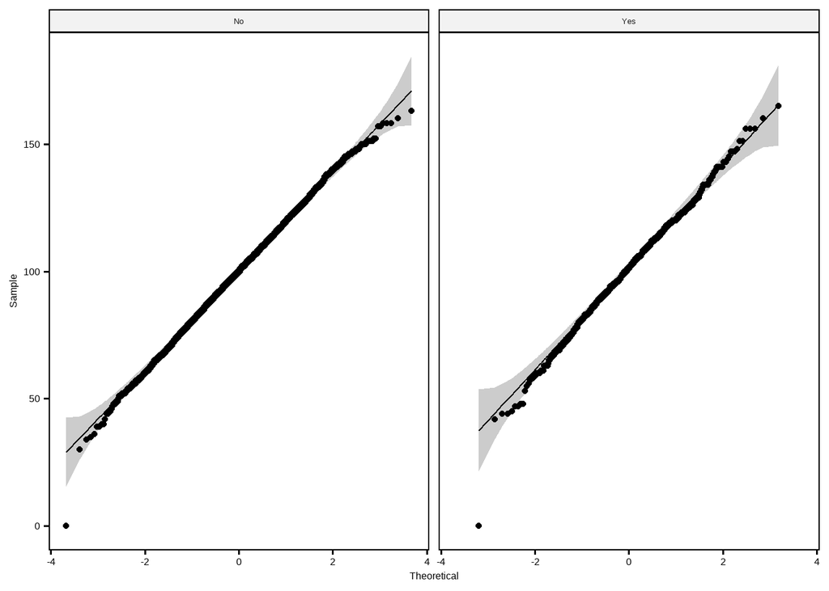

```r
ggqqplot(df, "totaldaycalls", facet.by = "churn")
```

### Variance test: `totaldaycalls` and `churn`

```r
leveneTest(totaldaycalls ~ churn, df)
```

```
## Levene's Test for Homogeneity of Variance (center = median)
##         Df F value Pr(>F)
## group    1  1.8561 0.1731
##       4998
```

The results from Levene’s Test for Homogeneity of Variance indicate that the null hypothesis, which assumes equal variances across groups, cannot be rejected. Therefore, we can conclude that there isn’t a significant difference in the variances of the `totaldaycalls` variable across different clusters. This suggests that the assumption of homogeneity of variances has not been violated.

### Between-Subjects Comparisons: `totaldaycalls` and `churn`

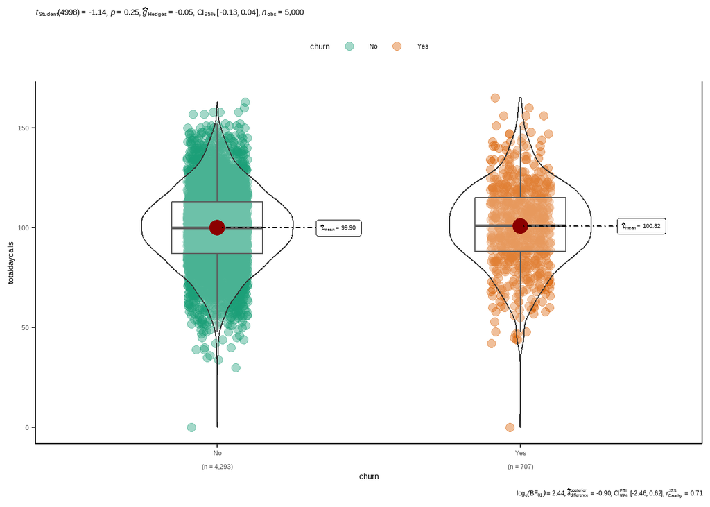

```r
ggbetweenstats(
  data = df,
  x    = churn,
  y    = totaldaycalls,
  type = "parametric",
  var.equal = TRUE
  ) +
  theme_classic() +
  theme(legend.position = "top")
```

Given that assumptions of normality and homogeneity of variance are not violated, a parametric statistical test with equal variance is employed. In this case, the Student’s t-test, a parametric method, is utilized.

Test results indicate that the null hypothesis cannot be rejected. This is supported by a p-value of 0.25 and a confidence interval of [-0.13, 0.04]. This finding suggests that there is no significant difference in the total number of calls the customer made during the day between the churn group and non-churn group.

### Interpretation of Effect Size: `totaldaycalls` and `churn`

```r
interpret_hedges_g(-0.05)
```

```
## [1] "very small"
## (Rules: cohen1988)
```

The Hedge’s g value of -0.05 is interpreted as ‘very small’ according to Cohen (1988) guidelines, indicating a very small effect size.

### Interpretation of Bayes Factor: `totaldaycalls` and `churn`

```r
interpret_bf(2.44,log = T)
```

```
## [1] "strong evidence in favour of"
## (Rules: jeffreys1961)
```

### Diagnosis of Outlier: `totaldaycalls` and `churn`

```r
df %>%
  group_by(churn) %>%
  diagnose_outlier(totaldaycalls) %>%
  flextable()
```

| variables | churn | data_cnt | outliers_cnt | outliers_ratio | outliers_mean | with_mean | without_mean |
| --- | --- | --- | --- | --- | --- | --- | --- |
| totaldaycalls | No | 4,293 | 23 | 0.5357559 | 74.65217 | 99.8996 | 100.0356 |
| totaldaycalls | Yes | 707 | 12 | 1.6973126 | 88.50000 | 100.8175 | 101.0302 |

Outlier diagnostics indicate that there is no presence of potentially influential outliers in the dataset. As a result, the application of robust statistical testing methods is not necessary.

## Chi-Square Test (Test of Association)

### Chi-Square Test (Test of Association): `voicemailplan` and `churn`

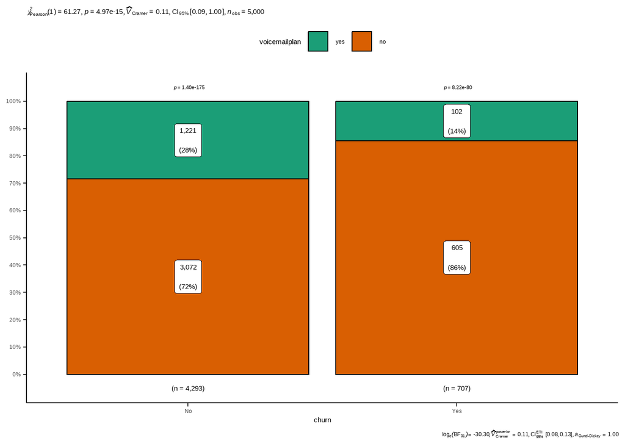

```r
ggbarstats(
  data  = df,
  x    = voicemailplan,
  y    = churn,
  label = "both",
) +
  theme_classic() +
  theme(legend.position = "top")
```

An examination of the association between `voicemailplan` and `churn` is conducted using a chi-square test. The test yields a p-value of 4.97e-15, significantly below the standard threshold of 0.05. This provides compelling evidence to reject the null hypothesis, which assumes independence between `voicemailplan` and `churn`.

Additionally, the confidence interval for this test ranges from 0.09 to 1.00. Given these results, a conclusion is drawn that there is a statistically significant association between the variables `voicemailplan` and `churn`. The proportions indicate that among customers who did not churn, 72% did not have a voicemail plan and 28% had a voicemail plan. Among customers who churned, 86% did not have a voicemail plan and 14% had a voicemail plan.

These proportions suggest that a larger percentage of customers without a voicemail plan ended up churning compared to those with a voicemail plan. Therefore, it could be inferred that customers without a voicemail plan are more likely to churn.

### Interpretation of Effect Size: `voicemailplan` and `churn`

```r
interpret_cramers_v(0.11)
```

```
## [1] "small"
## (Rules: funder2019)
```

The Cramers’ V value of 0.11 is interpreted as ‘small’ according to Funder & Ozer (2019) guidelines, indicating a small effect size.

### Interpretation of Bayes Factor: `voicemailplan` and `churn`

```r
interpret_bf(-30.30,log = T)
```

```
## [1] "extreme evidence against"
## (Rules: jeffreys1961)
```

### Chi-Square Test (Test of Association): `internationalplan` and `churn`

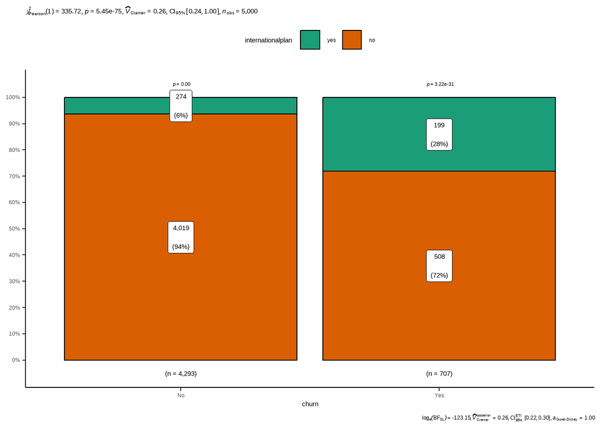

```r
ggbarstats(
  data  = df,
  x    = internationalplan,
  y    = churn,
  label = "both",
) +
  theme_classic() +
  theme(legend.position = "top")
```

An examination of the association between `internationalplan` and `churn` is conducted using a chi-square test. The test yields a p-value of 5.45e-75, significantly below the standard threshold of 0.05. This provides compelling evidence to reject the null hypothesis, which assumes independence between `internationalplan` and `churn`.

Additionally, the confidence interval for this test ranges from 0.24 to 1.00. Given these results, a conclusion is drawn that there is a statistically significant association between the variables `internationalplan` and `churn`. The proportions indicate that among customers who did not churn, 94% did not have an international plan and 6% had a an international plan. Among customers who churned, 72% did not have an international plan and 28% had an international plan.

These proportions suggest that a larger percentage of customers with an international plan ended up churning compared to those without an international plan. Therefore, it could be inferred that customers with an international plan are more likely to churn.

### Interpretation of Effect Size: `internationalplan` and `churn`

```r
interpret_cramers_v(0.26)
```

```
## [1] "medium"
## (Rules: funder2019)
```

### Interpretation of Bayes Factor: `internationalplan` and `churn`

```r
interpret_bf(-123.15,log = T)
```

```
## [1] "extreme evidence against"
## (Rules: jeffreys1961)
```

The Bayes Factor value of -123.15 is interpreted as ‘extreme evidence against’ according to Jeffreys (1961) guidelines, indicating extreme evidence against the null hypothesis.

### Chi-Square Test (Test of Association): `numbercustomerservicecalls` and `churn`

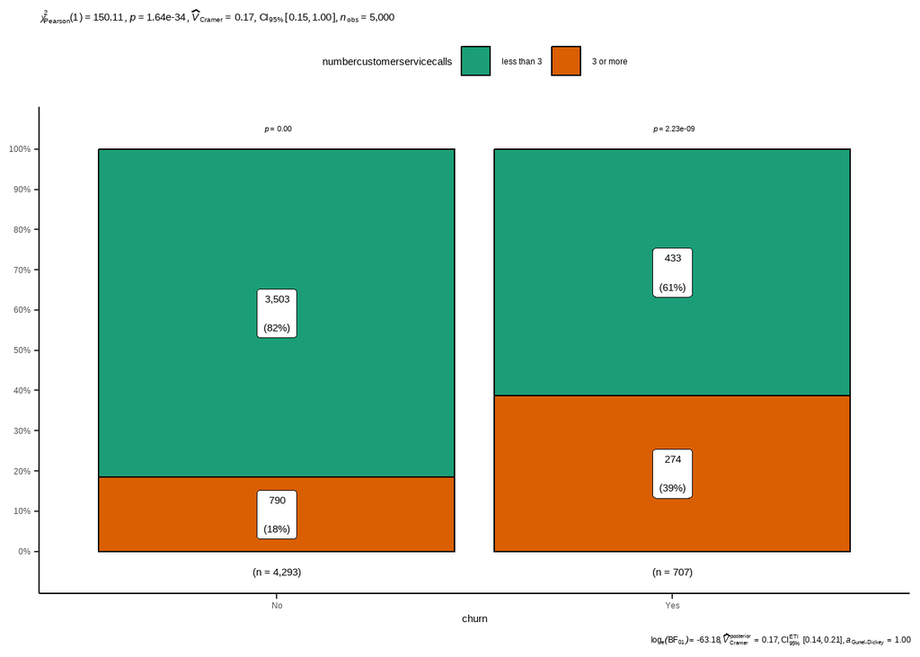

```r
ggbarstats(
  data  = df,
  x    = numbercustomerservicecalls,
  y    = churn,
  label = "both",
) +
  theme_classic() +
  theme(legend.position = "top")
```

An examination of the association between `numbercustomerservicecalls` and `churn` is conducted using a chi-square test. The test yields a p-value of 1.64e-34, significantly below the standard threshold of 0.05. This provides compelling evidence to reject the null hypothesis, which assumes independence between `numbercustomerservicecalls` and `churn`.

Additionally, the confidence interval for this test ranges from 0.15 to 1.00. Given these results, a conclusion is drawn that there is a statistically significant association between the variables `numbercustomerservicecalls` and `churn`. The proportions indicate that among customers who did not churn, 18% called customer service 3 or more times, while 82% called less than 3 times. In contrast, among those who churned, 39% called customer service 3 or more times, and 61% called less than 3 times.

These proportions suggest that a larger percentage of customers who called customer service 3 or more times ended up churning compared to those who called less than 3 times. Therefore, it could be inferred that customers who call customer service 3 or more times are more likely to churn.

### Interpretation of Effect Size: `numbercustomerservicecalls` and `churn`

```r
interpret_cramers_v(0.17)
```

```
## [1] "small"
## (Rules: funder2019)
```

The Cramers’ V value of 0.17 is interpreted as ‘small’ according to Funder & Ozer (2019) guidelines, indicating a small effect size.

### Interpretation of Bayes Factor: `numbercustomerservicecalls` and `churn`

```r
interpret_bf(-63.18,log = T)
```

```
## [1] "extreme evidence against"
## (Rules: jeffreys1961)
```

The Bayes Factor value of -63.18 is interpreted as ‘extreme evidence against’ according to Jeffreys (1961) guidelines, indicating extreme evidence against the null hypothesis.

### Chi-Square Test (Test of Association): `numbervmailmessages` and `churn`

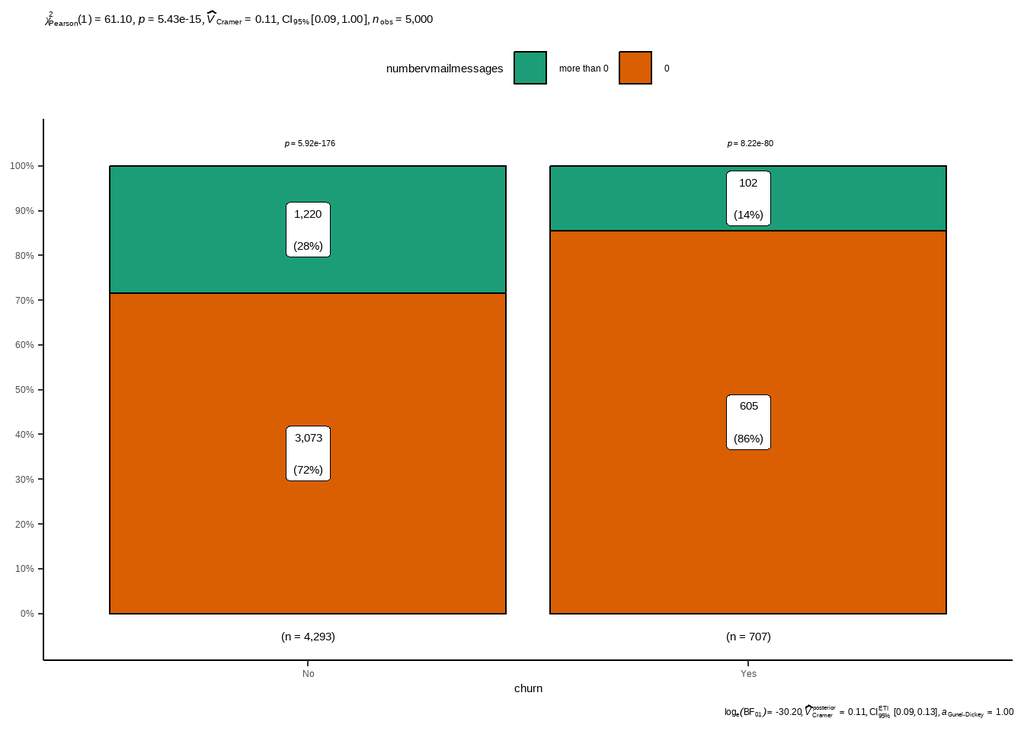

```r
ggbarstats(
  data  = df,
  x    = numbervmailmessages,
  y    = churn,
  label = "both",
) +
  theme_classic() +
  theme(legend.position = "top")
```

An examination of the association between `numbervmailmessages` and `churn` is conducted using a chi-square test. The test yields a p-value of 5.43e-15, significantly below the standard threshold of 0.05. This provides compelling evidence to reject the null hypothesis, which assumes independence between `numbervmailmessages` and `churn`.

Additionally, the confidence interval for this test ranges from 0.09 to 1.00. Given these results, a conclusion is drawn that there is a statistically significant association between the variables `numbervmailmessages` and `churn`. The proportions indicate that among customers who did not churn, 72% had no voicemail messages, while 28% had one or more voicemail messages. Conversely, among those who churned, 86% had no voicemail messages, and 14% had one or more voicemail messages.

These proportions suggest that a larger percentage of customers with no voicemail messages ended up churning compared to those with one or more voicemail messages. Therefore, it could be inferred that customers with no voicemail messages are more likely to churn.

### Interpretation of Effect Size: `numbervmailmessages` and `churn`

```r
interpret_cramers_v(0.11)
```

```
## [1] "small"
## (Rules: funder2019)
```

The Cramers’ V value of 0.11 is interpreted as ‘small’ according to Funder & Ozer (2019) guidelines, indicating a small effect size.

### Interpretation of Bayes Factor: `numbervmailmessages` and `churn`

```r
interpret_bf(-30.20,log = T)
```

```
## [1] "extreme evidence against"
## (Rules: jeffreys1961)
```

### Chi-Square Test (Test of Association): `totalintlcalls` and `churn`

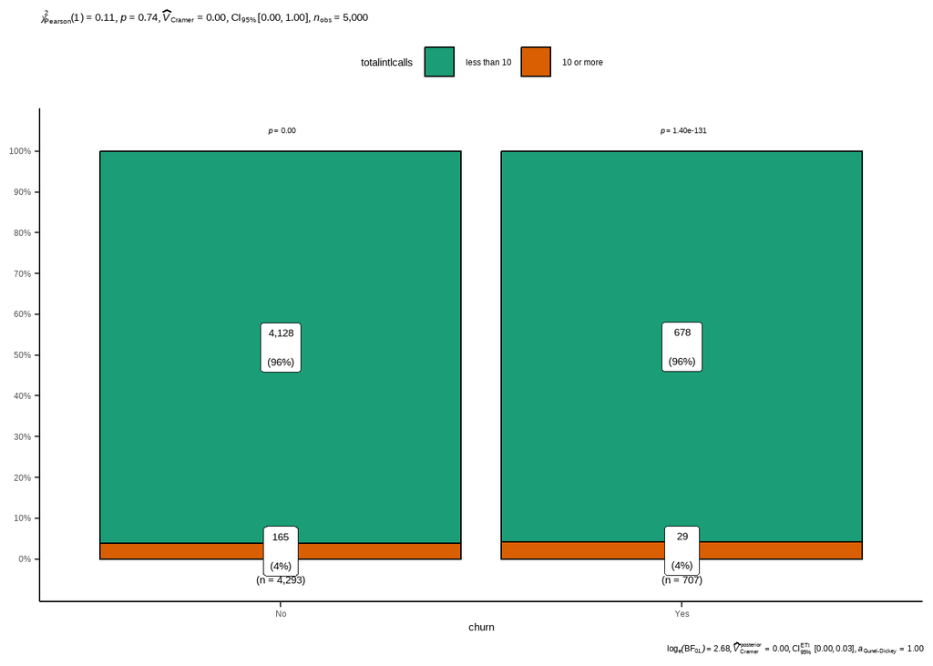

```r
ggbarstats(
  data  = df,
  x    = totalintlcalls,
  y    = churn,
  label = "both",
) +
  theme_classic() +
  theme(legend.position = "top")
```

An examination of the association between `totalintlcalls` and `churn` is conducted using a chi-square test. The test yields a p-value of 0.74, significantly exceeds the standard threshold of 0.05. This provides substantial evidence to retain the null hypothesis the null hypothesis, which assumes independence between `totalintlcalls` and `churn`.

Additionally, the confidence interval for this test ranges from 0.00 to 1.00. Given these results, a conclusion is drawn that there is no a statistically significant association between the variables `totalintlcalls` and `churn`.

### Interpretation of Bayes Factor: `totalintlcalls` and `churn`

```r
interpret_bf(2.68,log = T)
```

```
## [1] "strong evidence in favour of"
## (Rules: jeffreys1961)
```

# Conclusion and Recommendations

The aim of this analysis was to identify the factors contributing to customer churn. Based on the results, several key insights emerge:

1. **Usage Patterns**: Significant differences in the total number of minutes used during the day, evening, and night, as well as the total charge for day, evening, international, and night usage were observed between the churn group and non-churn group. Monitoring these usage patterns could help identify customers who are likely to churn.
2. **Customer Service**: The analysis found a significant association between the number of customer service calls and churn. Customers who call customer service 3 or more times are more likely to churn. This suggests that improving customer service could help reduce churn.
3. **Voicemail Plan**: A significant association was found between voicemail plan and churn. Customers without a voicemail plan are more likely to churn. Therefore, promoting the benefits of having a voicemail plan to customers could help reduce churn.
4. **International Plan**: A significant association was found between international plan and churn. Customers with an international plan are more likely to churn. This suggests that reviewing the pricing and features of the international plan could help retain these customers.
5. **Voicemail Messages**: A significant association was found between the number of voicemail messages and churn. Customers with no voicemail messages are more likely to churn. Engaging these customers through other communication channels could help reduce churn.

No statistically significant association was found between totalintlcalls and churn.

These insights provide valuable information about customer behavior and can inform strategies to reduce customer churn. The strategies suggested here can be tested and refined over time to optimize their effectiveness in reducing customer churn.